# Auswertung TC Daten

David Lilek

14 Juli 2023, 12:59:01

```r
results_comp <- c()
length_comp <- c()
```

# 1 Load Libraries & Plot function & Colors

```r
library(ggplot2)
library(tidyverse)
library(dplyr)
library(UpSetR)
library(pheatmap)
library(ggvenn)
library(knitr)
library(reshape2)
library(eulerr)
library(UniprotR)
library(stringr)
#library(venneuler)
#library(VennDiagram)
```

```r
# Function to extract and remove square brackets from a string
extract_goterm <- function(input_string) {
  # Extract the first string between square brackets
  extracted_string <- str_extract(input_string, "\\[(.*?)\\]")

  # Remove the square brackets
  extracted_string <- str_remove_all(extracted_string, "\\[|\\]")

  # Return the extracted string
  return(extracted_string)
}
```

```r
#get colors
#total protein extract
total <- rgb(255,93,93, maxColorValue = 255)
#fractions high MW SEC
highMW <- rgb(169,208,142,maxColorValue = 255)
#fractions low MW SEC
lowMW <- rgb(255,217,102, maxColorValue = 255)
#in-gel digest
IG <- rgb(180,198,231,maxColorValue = 255)
```

# 2 Überblick

- für die ausgewählten Grafiken des Papers wurden die Proteine (und zwar nur das erste einer Proteingruppe) mittels des Packages `UniprotR` einer molekularen, biologischen Funktion bzw einem zellulärem Compartment zugeordnet
- UniprotR
- Ablauf: einlesen der Daten und extrahieren der Accesion Number und mittels Funktion `GetProteinGOInfo` die Daten vom UniProt Server gelesen
- diese GO Terms dann je Extraktion zb E4_D1_pool und absteigender Frequenz sortiert und die besten 20 geplottet wobei dabei nicht zuordenbare Accessionnumbers ignoriert wurden (bei ein paar habe ich es mir angeschaut und es sind so 10-20% die nicht zuordenbar sind)
- zuerst von allen functionen die besten 20 auswählen
- die werden dann gemerged
- dann eben geschaut wieviel NA im Vergleich in Probe A (spalte 2) sind; das sind dann die proteine die mehr in Probe B sind; wenn man dann schaut wieviele in Summe gefunden wurden kriegt man die %

`results_comp <- c(results_comp,sum(is.na(BP[2])))` `rength_comp <- c(length_comp, length(BP[,1]))`

- [Zusatzinfo GO Terms Uniprot](http://geneontology.org/docs/ontology-documentation/)
- [Zusatzinfo Panther DB](http://www.pantherdb.org/about.jsp) ## Erklärung Judith WIE KOMME ICH AUF DIE MOLEKULAREN FUNKTIONEN DIE WIR MEHR ODER WENIGER FINDEN?

Ich habe zb zwei Proben X und Y. Bei beiden ordne ich die molekularen Funktionen über die FASTA identifier zu. Das geht indem man automatisch auf Uniprot zugreift und es gibt dafür ein Package in R.

Ich sortiere dann die molekularen Funktionen nach Häufigkeit - es kann ja sein, dass mehrere Proteine der Gruppe Oxidoreductase Aktivität haben - und zwar für X und Y. Dann merge ich die beiden und das Ergebnis sieht so aus…

In Spalte Var1 steht eben die molecular function. In Spalte Freq.X bzw Freq.Y wie oft diese Molecular Function vorgekommen ist.

Wie komme ich jetzt auf die neuen Molecular Functions die ich in Y mehr finde als in X? Ich schaue einfach in der Spalte Freq.X wie oft durch NA steht weil diese Funktion eben nur in Y vorkommt. Da kommt dann in diesem Beispiel 3 NA values. Wenn in Summe 19 Zeilen sind, dann habe ich 3/19=15,8% neue molekulare Funktionen in Y.

## 2.1 am 13.07 geprüft

# 3 Grafik 1

- fehlt weil ja uninteressant für diesen Vergleich

# 4 Grafik 2

## 4.1 A

```r
# D1-D2 comparison

D1_raw <- readRDS(file = "results_v002/results_run1_mqpar_extracts_2gether_E4_D1_a-j_LFQ_combined_txt_proteinGroups.txt_Unique.RDS")
D1_raw <- D1_raw[[1]]
D1 <- dplyr::select(D1_raw, contains("Pool"))
D1 <- apply(D1, 1, any)
#D1 <- as.data.frame(cbind(D1, D1_raw$FASTA))
fasta <- c()
for (i in 1:length(D1_raw$FASTA)){
  tmp <- strsplit(D1_raw$FASTA[i],split='\\|')[[1]][2]
  fasta <- c(fasta,tmp)
}
D1 <- as.data.frame(cbind(D1, fasta))
D2_raw <- readRDS(file = "results_v002/results_run1_mqpar_extracts_2gether_D2_LFQ_combined_txt_proteinGroups.txt_Unique.RDS")
D2_raw <- D2_raw[[1]]
D2 <- dplyr::select(D2_raw, contains("Gesamt"))
D2 <- apply(D2, 1, any)
fasta <- c()
for (i in 1:length(D2_raw$FASTA)){
  tmp <- strsplit(D2_raw$FASTA[i],split='\\|')[[1]][2]
  fasta <- c(fasta,tmp)
}
#D2 <- as.data.frame(cbind(D2, D2_raw$FASTA))
D2 <- as.data.frame(cbind(D2, fasta))
D1_D2_comparison  <- merge(D1, D2,
                           all = TRUE,
                           by = "fasta")

D1_D2_comparison$D1 <- as.logical(D1_D2_comparison$D1)
D1_D2_comparison$D2 <- as.logical(D1_D2_comparison$D2)

D1 <- D1_D2_comparison$fasta[D1_D2_comparison$D1]
D1 <- D1[!is.na(D1)]
D2 <- D1_D2_comparison$fasta[D1_D2_comparison$D2]
D2 <- D2[!is.na(D2)]
#D1_uni <- GetProteinGOInfo(D1)
#saveRDS(D1_uni,"./go_terms/graph2_D1_uni.RDS")
GO_1 <- readRDS("./go_terms/graph2_D1_uni.RDS")
#D2_uni <- GetProteinGOInfo(D2)
#saveRDS(D2_uni,"./go_terms/graph2_D2_uni.RDS")
GO_2 <- readRDS("./go_terms/graph2_D2_uni.RDS")

################################# Biological process
t_BP <- as.data.frame(table(GO_1$Gene.Ontology..biological.process.))
t_BP_sorted <- arrange(t_BP, desc(Freq))
t_BP_sorted_1 <- t_BP_sorted[c(1:20),]
t_BP <- as.data.frame(table(GO_2$Gene.Ontology..biological.process.))
t_BP_sorted <- arrange(t_BP, desc(Freq))
t_BP_sorted_2 <- t_BP_sorted[c(1:20),]
#t_BP <- as.data.frame(table(GO[[3]]$Gene.ontology..biological.process.))
#t_BP_sorted <- arrange(t_BP, desc(Freq))
#t_BP_sorted_3 <- t_BP_sorted[c(1:20),]
BP <- merge(t_BP_sorted_1, t_BP_sorted_2,
            all = TRUE,
            by = "Var1")
#BP <- merge(BP, t_BP_sorted_3, all = TRUE, by = "Var1")
colnames(BP) <- c("Function", "D1","D2")
kable(BP)
```

| Function | D1 | D2 |
| --- | --- | --- |
| carbohydrate metabolic process [GO:0005975] | 7 | 3 |
| carbohydrate metabolic process [GO:0005975]; chitin catabolic process [GO:0006032] | 3 | 6 |
| ceramide biosynthetic process [GO:0046513]; sphingomyelin catabolic process [GO:0006685] | 3 | NA |
| cytoplasmic translation [GO:0002181] | 6 | 6 |
| fatty acid beta-oxidation [GO:0006635] | 8 | 6 |
| fatty acid biosynthetic process [GO:0006633] | 4 | NA |
| glutathione metabolic process [GO:0006749] | 6 | 5 |
| glycolytic process [GO:0006096] | NA | 3 |
| microtubule-based movement [GO:0007018] | NA | 3 |
| mitochondrial electron transport, cytochrome c to oxygen [GO:0006123] | NA | 4 |
| mitochondrial electron transport, NADH to ubiquinone [GO:0006120] | NA | 6 |
| mitochondrial electron transport, ubiquinol to cytochrome c [GO:0006122] | 3 | 4 |
| mitochondrion organization [GO:0007005] | NA | 3 |
| mitotic cytokinesis [GO:0000281] | NA | 3 |
| multicellular organism reproduction [GO:0032504] | 3 | 3 |
| peptide catabolic process [GO:0043171]; proteolysis [GO:0006508] | 4 | NA |
| proteasomal protein catabolic process [GO:0010498] | 4 | NA |
| proteasomal protein catabolic process [GO:0010498]; ubiquitin-dependent protein catabolic process [GO:0006511] | 3 | NA |
| proteasome-mediated ubiquitin-dependent protein catabolic process [GO:0043161] | 9 | 5 |
| protein folding [GO:0006457] | 6 | 5 |
| proteolysis [GO:0006508] | 19 | 8 |
| proteolysis involved in protein catabolic process [GO:0051603]; regulation of catalytic activity [GO:0050790] | 4 | NA |
| proton motive force-driven ATP synthesis [GO:0015986] | 6 | 6 |
| regulation of muscle contraction [GO:0006937]; skeletal muscle contraction [GO:0003009] | 3 | NA |
| sensory perception of smell [GO:0007608] | 3 | NA |
| translation [GO:0006412] | 22 | 20 |
| long-chain fatty-acyl-CoA metabolic process [GO:0035336] | NA | 3 |
| transmembrane transport [GO:0055085] | NA | 4 |

```r
kable(BP[is.na(BP[,3])==TRUE,1])
```

| x |
| --- |
| ceramide biosynthetic process [GO:0046513]; sphingomyelin catabolic process [GO:0006685] |
| fatty acid biosynthetic process [GO:0006633] |
| peptide catabolic process [GO:0043171]; proteolysis [GO:0006508] |
| proteasomal protein catabolic process [GO:0010498] |
| proteasomal protein catabolic process [GO:0010498]; ubiquitin-dependent protein catabolic process [GO:0006511] |
| proteolysis involved in protein catabolic process [GO:0051603]; regulation of catalytic activity [GO:0050790] |
| regulation of muscle contraction [GO:0006937]; skeletal muscle contraction [GO:0003009] |
| sensory perception of smell [GO:0007608] |

```r
kable(BP[is.na(BP[,2])==TRUE,1])
```

| x |
| --- |
| glycolytic process [GO:0006096] |
| microtubule-based movement [GO:0007018] |
| mitochondrial electron transport, cytochrome c to oxygen [GO:0006123] |
| mitochondrial electron transport, NADH to ubiquinone [GO:0006120] |
| mitochondrion organization [GO:0007005] |
| mitotic cytokinesis [GO:0000281] |
| long-chain fatty-acyl-CoA metabolic process [GO:0035336] |
| transmembrane transport [GO:0055085] |

```r
BP[is.na(BP[,3])==TRUE,1]
```

```
## [1] ceramide biosynthetic process [GO:0046513]; sphingomyelin catabolic process [GO:0006685]
## [2] fatty acid biosynthetic process [GO:0006633]
## [3] peptide catabolic process [GO:0043171]; proteolysis [GO:0006508]
## [4] proteasomal protein catabolic process [GO:0010498]
## [5] proteasomal protein catabolic process [GO:0010498]; ubiquitin-dependent protein catabolic process [GO:0006511]
## [6] proteolysis involved in protein catabolic process [GO:0051603]; regulation of catalytic activity [GO:0050790]
## [7] regulation of muscle contraction [GO:0006937]; skeletal muscle contraction [GO:0003009]
## [8] sensory perception of smell [GO:0007608]
## 446 Levels: 'de novo' AMP biosynthetic process [GO:0044208]; 'de novo' IMP biosynthetic process [GO:0006189] ...
```

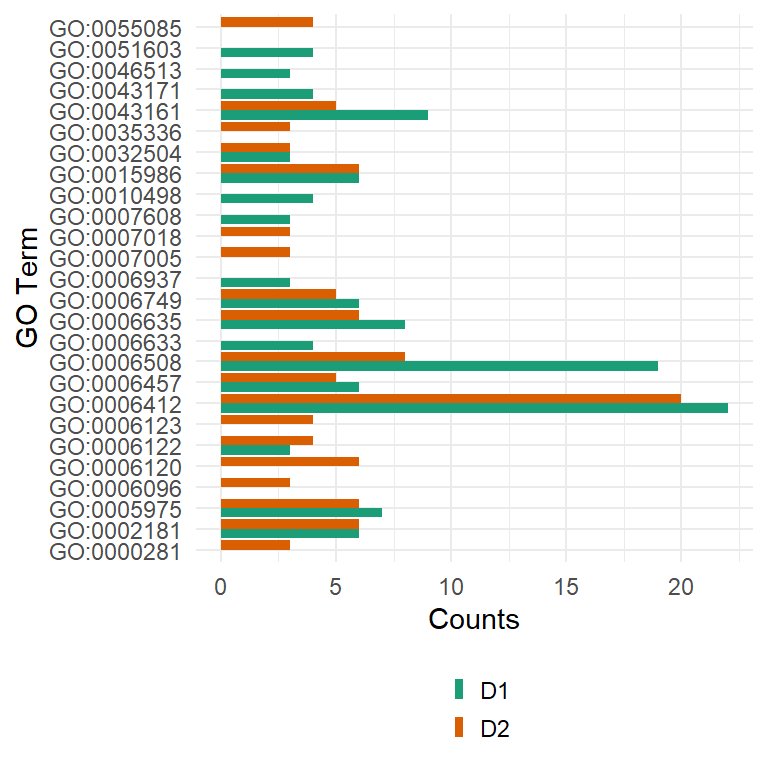

```r
BP_4ggplot <- melt(BP)
#BP_4ggplot$Function_short <- substr(BP_4ggplot$Function,1,15)
BP_4ggplot <- BP_4ggplot %>%
  mutate(Function_short = extract_goterm(Function))
ggplot(BP_4ggplot, aes(x=Function_short, y=value, fill=variable)) +
  geom_bar(stat='identity', position='dodge') +
  theme_minimal() +
  scale_fill_brewer(palette="Dark2") +
  theme(legend.position="bottom") +
  theme(legend.key.size = unit(0.15, 'cm')) +
  guides(fill=guide_legend(nrow=2, byrow=TRUE)) +
  ylab("Counts") +
  xlab("GO Term") +
  labs(fill = "") +
  coord_flip() +
  theme(legend.title = element_blank())
```

```r
################################# molecular function
t_BP <- as.data.frame(table(GO_1$Gene.Ontology..molecular.function.))
t_BP_sorted <- arrange(t_BP, desc(Freq))
t_BP_sorted_1 <- t_BP_sorted[c(1:20),]
t_BP <- as.data.frame(table(GO_2$Gene.Ontology..molecular.function.))
t_BP_sorted <- arrange(t_BP, desc(Freq))
t_BP_sorted_2 <- t_BP_sorted[c(1:20),]
#t_BP <- as.data.frame(table(GO_3$Gene.Ontology..molecular.function.))
#t_BP_sorted <- arrange(t_BP, desc(Freq))
#t_BP_sorted_3 <- t_BP_sorted[c(1:20),]
BP <- merge(t_BP_sorted_1, t_BP_sorted_2,
            all = TRUE,
            by = "Var1")
#BP <- merge(BP, t_BP_sorted_3, all = TRUE, by = "Var1")
results_comp <- sum(is.na(BP[2]))
length_comp <- length(BP[,1])
colnames(BP) <- c("Function", "D1: Phosphate buffer", "D2: Phosphate buffer with urea-triton X")
kable(BP)
```

| Function | D1: Phosphate buffer | D2: Phosphate buffer with urea-triton X |
| --- | --- | --- |
| acid sphingomyelin phosphodiesterase activity [GO:0061750]; hydrolase activity, acting on glycosyl bonds [GO:0016798]; metal ion binding [GO:0046872]; phosphoric diester hydrolase activity [GO:0008081… | 3 | NA |
| actin filament binding [GO:0051015] | 5 | 3 |
| actin filament binding [GO:0051015]; calcium ion binding [GO:0005509]; calcium-dependent protein binding [GO:0048306] | 3 | NA |
| ATP binding [GO:0005524]; ATP hydrolysis activity [GO:0016887]; ATP-dependent protein folding chaperone [GO:0140662]; unfolded protein binding [GO:0051082] | 6 | 6 |
| ATP binding [GO:0005524]; ATP hydrolysis activity [GO:0016887]; peptidase activity [GO:0008233]; proteasome-activating activity [GO:0036402] | 6 | 4 |
| calcium ion binding [GO:0005509] | 8 | 6 |
| calcium ion binding [GO:0005509]; calcium-dependent phospholipid binding [GO:0005544] | 3 | 3 |
| chitin binding [GO:0008061] | 3 | NA |
| chitin binding [GO:0008061]; chitinase activity [GO:0004568] | NA | 4 |
| cysteine-type endopeptidase activity [GO:0004197] | 5 | 3 |
| DNA binding [GO:0003677]; protein heterodimerization activity [GO:0046982]; structural constituent of chromatin [GO:0030527] | 3 | NA |
| endopeptidase activity [GO:0004175]; threonine-type endopeptidase activity [GO:0004298] | 3 | NA |
| glutathione transferase activity [GO:0004364] | 5 | 5 |
| GTP binding [GO:0005525]; GTPase activity [GO:0003924] | 3 | 6 |
| GTP binding [GO:0005525]; GTPase activity [GO:0003924]; translation elongation factor activity [GO:0003746] | NA | 3 |
| heme binding [GO:0020037]; iron ion binding [GO:0005506]; monooxygenase activity [GO:0004497]; oxidoreductase activity, acting on paired donors, with incorporation or reduction of molecular oxygen [GO… | NA | 13 |
| hydrolase activity [GO:0016787] | 6 | 4 |
| metal ion binding [GO:0046872] | NA | 4 |
| oxidoreductase activity [GO:0016491] | 5 | NA |
| proton-transporting ATPase activity, rotational mechanism [GO:0046961] | NA | 5 |
| RNA binding [GO:0003723] | 4 | NA |
| RNA binding [GO:0003723]; structural constituent of ribosome [GO:0003735] | 16 | 16 |
| serine-type endopeptidase activity [GO:0004252] | 8 | NA |
| structural constituent of chitin-based larval cuticle [GO:0008010] | NA | 13 |
| structural constituent of ribosome [GO:0003735] | 24 | 20 |
| structural molecule activity [GO:0005198] | 5 | NA |
| alcohol-forming fatty acyl-CoA reductase activity [GO:0102965]; fatty-acyl-CoA reductase (alcohol-forming) activity [GO:0080019] | NA | 3 |
| glucuronosyltransferase activity [GO:0015020] | NA | 3 |
| structural constituent of cuticle [GO:0042302] | NA | 8 |

```r
kable(BP[is.na(BP[,3])==TRUE,1])
```

| x |
| --- |
| acid sphingomyelin phosphodiesterase activity [GO:0061750]; hydrolase activity, acting on glycosyl bonds [GO:0016798]; metal ion binding [GO:0046872]; phosphoric diester hydrolase activity [GO:0008081… |
| actin filament binding [GO:0051015]; calcium ion binding [GO:0005509]; calcium-dependent protein binding [GO:0048306] |
| chitin binding [GO:0008061] |
| DNA binding [GO:0003677]; protein heterodimerization activity [GO:0046982]; structural constituent of chromatin [GO:0030527] |
| endopeptidase activity [GO:0004175]; threonine-type endopeptidase activity [GO:0004298] |
| oxidoreductase activity [GO:0016491] |
| RNA binding [GO:0003723] |
| serine-type endopeptidase activity [GO:0004252] |
| structural molecule activity [GO:0005198] |

```r
kable(BP[is.na(BP[,2])==TRUE,1])
```

| x |
| --- |
| chitin binding [GO:0008061]; chitinase activity [GO:0004568] |
| GTP binding [GO:0005525]; GTPase activity [GO:0003924]; translation elongation factor activity [GO:0003746] |
| heme binding [GO:0020037]; iron ion binding [GO:0005506]; monooxygenase activity [GO:0004497]; oxidoreductase activity, acting on paired donors, with incorporation or reduction of molecular oxygen [GO… |
| metal ion binding [GO:0046872] |
| proton-transporting ATPase activity, rotational mechanism [GO:0046961] |
| structural constituent of chitin-based larval cuticle [GO:0008010] |
| alcohol-forming fatty acyl-CoA reductase activity [GO:0102965]; fatty-acyl-CoA reductase (alcohol-forming) activity [GO:0080019] |
| glucuronosyltransferase activity [GO:0015020] |
| structural constituent of cuticle [GO:0042302] |

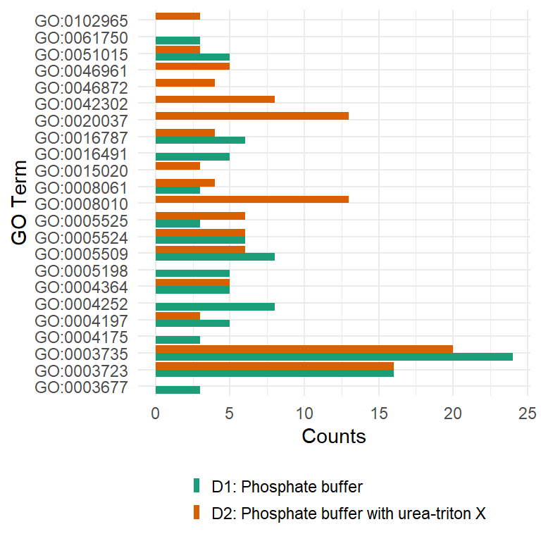

```r
BP_4ggplot <- melt(BP)
#BP_4ggplot$Function_short <- substr(BP_4ggplot$Function,1,15)
BP_4ggplot <- BP_4ggplot %>%
  mutate(Function_short = extract_goterm(Function))
ggplot(BP_4ggplot, aes(x=Function_short, y=value, fill=variable)) +
  geom_bar(stat='identity', position='dodge') +
  theme_minimal() +
  scale_fill_brewer(palette="Dark2") +
  theme(legend.position="bottom") +
  theme(legend.key.size = unit(0.15, 'cm')) +
  guides(fill=guide_legend(nrow=2, byrow=TRUE)) +
  ylab("Counts") +
  xlab("GO Term") +
  labs(fill = "") +
  coord_flip() +
  theme(legend.title = element_blank())
```

```r
################################# cellular.component
t_BP <- as.data.frame(table(GO_1$Gene.Ontology..cellular.component.))
t_BP_sorted <- arrange(t_BP, desc(Freq))
t_BP_sorted_1 <- t_BP_sorted[c(1:20),]
t_BP <- as.data.frame(table(GO_2$Gene.Ontology..cellular.component.))
t_BP_sorted <- arrange(t_BP, desc(Freq))
t_BP_sorted_2 <- t_BP_sorted[c(1:20),]
#t_BP <- as.data.frame(table(GO_3$Gene.Ontology..cellular.component.))
#t_BP_sorted <- arrange(t_BP, desc(Freq))
#t_BP_sorted_3 <- t_BP_sorted[c(1:20),]
BP <- merge(t_BP_sorted_1, t_BP_sorted_2,
            all = TRUE,
            by = "Var1")
#BP <- merge(BP, t_BP_sorted_3, all = TRUE, by = "Var1")
colnames(BP) <- c("Function", "D1","D2")
kable(BP)
```

| Function | D1 | D2 |
| --- | --- | --- |
| chaperonin-containing T-complex [GO:0005832] | 4 | 4 |
| chitin-based extracellular matrix [GO:0062129] | NA | 13 |
| cytoplasm [GO:0005737] | 59 | 27 |
| cytoplasm [GO:0005737]; mitochondrion [GO:0005739] | 4 | NA |
| cytoplasm [GO:0005737]; nucleus [GO:0005634] | 5 | 5 |
| cytosol [GO:0005829] | 27 | 16 |
| cytosol [GO:0005829]; mitochondrion [GO:0005739] | 4 | NA |
| cytosolic large ribosomal subunit [GO:0022625] | 24 | 24 |
| cytosolic small ribosomal subunit [GO:0022627] | 10 | 10 |
| endoplasmic reticulum [GO:0005783]; membrane [GO:0016020] | NA | 5 |
| endoplasmic reticulum membrane [GO:0005789] | NA | 9 |
| eukaryotic 43S preinitiation complex [GO:0016282]; eukaryotic 48S preinitiation complex [GO:0033290]; eukaryotic translation initiation factor 3 complex [GO:0005852] | 4 | NA |
| extracellular region [GO:0005576] | 9 | 11 |
| extracellular space [GO:0005615] | 9 | 8 |
| extracellular space [GO:0005615]; lysosome [GO:0005764] | 8 | NA |
| membrane [GO:0016020] | 8 | 40 |
| membrane [GO:0016020]; mitochondrion [GO:0005739] | NA | 5 |
| mitochondrial inner membrane [GO:0005743] | NA | 8 |
| mitochondrial matrix [GO:0005759] | 6 | NA |
| mitochondrial respiratory chain complex I [GO:0005747] | NA | 12 |
| mitochondrial respiratory chain complex IV [GO:0005751] | NA | 5 |
| mitochondrion [GO:0005739] | 30 | 22 |
| nucleus [GO:0005634] | 7 | NA |
| peroxisome [GO:0005777] | 9 | NA |
| plasma membrane [GO:0005886] | 4 | 6 |
| ribonucleoprotein complex [GO:1990904]; ribosome [GO:0005840] | 4 | 5 |
| troponin complex [GO:0005861] | 4 | NA |
| extracellular matrix [GO:0031012] | NA | 8 |

```r
kable(BP[is.na(BP[,3])==TRUE,1])
```

| x |
| --- |
| cytoplasm [GO:0005737]; mitochondrion [GO:0005739] |
| cytosol [GO:0005829]; mitochondrion [GO:0005739] |
| eukaryotic 43S preinitiation complex [GO:0016282]; eukaryotic 48S preinitiation complex [GO:0033290]; eukaryotic translation initiation factor 3 complex [GO:0005852] |
| extracellular space [GO:0005615]; lysosome [GO:0005764] |
| mitochondrial matrix [GO:0005759] |
| nucleus [GO:0005634] |
| peroxisome [GO:0005777] |
| troponin complex [GO:0005861] |

```r
kable(BP[is.na(BP[,2])==TRUE,1])
```

| x |
| --- |
| chitin-based extracellular matrix [GO:0062129] |
| endoplasmic reticulum [GO:0005783]; membrane [GO:0016020] |
| endoplasmic reticulum membrane [GO:0005789] |
| membrane [GO:0016020]; mitochondrion [GO:0005739] |
| mitochondrial inner membrane [GO:0005743] |
| mitochondrial respiratory chain complex I [GO:0005747] |
| mitochondrial respiratory chain complex IV [GO:0005751] |
| extracellular matrix [GO:0031012] |

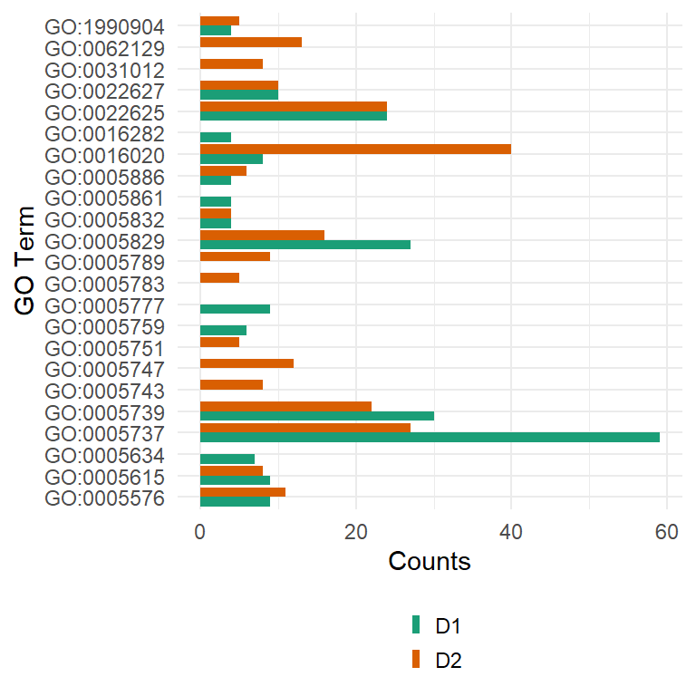

```r
BP_4ggplot <- melt(BP)
#BP_4ggplot$Function_short <- substr(BP_4ggplot$Function,1,15)
BP_4ggplot <- BP_4ggplot %>%
  mutate(Function_short = extract_goterm(Function))
ggplot(BP_4ggplot, aes(x=Function_short, y=value, fill=variable)) +
  geom_bar(stat='identity', position='dodge') +
  theme_minimal() +
  scale_fill_brewer(palette="Dark2") +
  theme(legend.position="bottom") +
  theme(legend.key.size = unit(0.15, 'cm')) +
  guides(fill=guide_legend(nrow=2, byrow=TRUE)) +
  ylab("Counts") +
  xlab("GO Term") +
  labs(fill = "") +
  coord_flip() +
  theme(legend.title = element_blank())
```

## 4.2 B

```r
data <- readRDS("./27_20230201_FH/results/D5_extracts_Razor.RDS")
data <- data[[1]]
b <- dplyr::select(data, contains("_b"))
D1_b <- b$Razor...unique.peptides.1_b_01+ b$Razor...unique.peptides.1_b_02
D2_b <- b$Razor...unique.peptides.2_b_01 + b$Razor...unique.peptides.2_b_02
D4_b <- b$Razor...unique.peptides.3_b_01 + b$Razor...unique.peptides.4_b_02
b <- as.data.frame(cbind(D1_b,D2_b,D4_b))
b[b==0] <- NA
b[b==2] <- 1

fasta <- c()
for (i in 1:length(data$FASTA)){
  tmp <- strsplit(data$FASTA[i],split='\\|')[[1]][2]
  fasta <- c(fasta,tmp)
}

E5_D1_b <- fasta[as.logical(b$Razor...unique.peptides.1_b_01)]
E5_D1_b <- E5_D1_b[!is.na(E5_D1_b)]
E5_D2_b <- fasta[as.logical(b$Razor...unique.peptides.2_b_01)]
E5_D2_b <- E5_D2_b[!is.na(E5_D2_b)]
E5_D4_b <- fasta[as.logical(b$Razor...unique.peptides.3_b_01)]
E5_D4_b <- E5_D4_b[!is.na(E5_D4_b)]



#D1_uni <- GetProteinGOInfo(E5_D1_b)
#saveRDS(D1_uni,"./go_terms/graph2_E5_D1_uni.RDS")
GO_1 <- readRDS("./go_terms/graph2_E5_D1_uni.RDS")
#D2_uni <- GetProteinGOInfo(E5_D2_b)
#saveRDS(D2_uni,"./go_terms/graph2_E5_D2_uni.RDS")
GO_2 <- readRDS("./go_terms/graph2_E5_D2_uni.RDS")
#D4_uni <- GetProteinGOInfo(E5_D4_b)
#saveRDS(D4_uni,"./go_terms/graph2_E5_D4_uni.RDS")
GO_3 <- readRDS("./go_terms/graph2_E5_D4_uni.RDS")
################################# Biological process
t_BP <- as.data.frame(table(GO_1$Gene.Ontology..biological.process.))
t_BP_sorted <- arrange(t_BP, desc(Freq))
t_BP_sorted_1 <- t_BP_sorted[c(1:20),]
t_BP <- as.data.frame(table(GO_2$Gene.Ontology..biological.process.))
t_BP_sorted <- arrange(t_BP, desc(Freq))
t_BP_sorted_2 <- t_BP_sorted[c(1:20),]
t_BP <- as.data.frame(table(GO_3$Gene.Ontology..biological.process.))
t_BP_sorted <- arrange(t_BP, desc(Freq))
t_BP_sorted_3 <- t_BP_sorted[c(1:20),]
BP <- merge(t_BP_sorted_1, t_BP_sorted_2,
            all = TRUE,
            by = "Var1")
BP <- merge(BP, t_BP_sorted_3, all = TRUE, by = "Var1")
colnames(BP) <- c("Function", "D1","D2","D4")
kable(BP)
```

| Function | D1 | D2 | D4 |
| --- | --- | --- | --- |
| actin cytoskeleton organization [GO:0030036] | NA | NA | 2 |
| actin filament organization [GO:0007015]; muscle contraction [GO:0006936] | NA | NA | 2 |
| anatomical structure morphogenesis [GO:0009653]; cell differentiation [GO:0030154]; protein phosphorylation [GO:0006468] | NA | NA | 2 |
| ATP synthesis coupled electron transport [GO:0042773] | NA | NA | 2 |
| bioluminescence [GO:0008218] | 4 | NA | NA |
| bioluminescence [GO:0008218]; fatty-acyl-CoA biosynthetic process [GO:0046949]; long-chain fatty acid metabolic process [GO:0001676] | 4 | NA | NA |
| carbohydrate metabolic process [GO:0005975] | 7 | 6 | 3 |
| carbohydrate metabolic process [GO:0005975]; chitin catabolic process [GO:0006032] | 3 | 4 | 4 |
| cell-matrix adhesion [GO:0007160] | NA | NA | 2 |
| cell adhesion [GO:0007155] | NA | 3 | NA |
| cristae formation [GO:0042407] | NA | 3 | NA |
| cytoplasmic translation [GO:0002181] | 6 | 6 | 5 |
| fatty acid beta-oxidation [GO:0006635] | 8 | 9 | 5 |
| fatty acid biosynthetic process [GO:0006633] | 4 | NA | NA |
| fatty acid metabolic process [GO:0006631] | NA | 3 | NA |
| glutathione metabolic process [GO:0006749] | 8 | 5 | NA |
| glycolytic process [GO:0006096] | NA | 3 | 3 |
| long-chain fatty-acyl-CoA metabolic process [GO:0035336] | NA | 3 | NA |
| mitochondrial electron transport, cytochrome c to oxygen [GO:0006123] | 4 | 4 | 4 |
| mitochondrial electron transport, NADH to ubiquinone [GO:0006120] | 6 | 10 | 7 |
| mitochondrial electron transport, ubiquinol to cytochrome c [GO:0006122] | NA | 4 | 4 |
| mitochondrion organization [GO:0007005] | NA | NA | 3 |
| mitotic cytokinesis [GO:0000281] | NA | NA | 3 |
| multicellular organism reproduction [GO:0032504] | 4 | 4 | NA |
| nitrogen compound metabolic process [GO:0006807] | NA | NA | 3 |
| peptide catabolic process [GO:0043171]; proteolysis [GO:0006508] | 4 | NA | NA |
| proteasomal protein catabolic process [GO:0010498] | 4 | NA | NA |
| proteasome-mediated ubiquitin-dependent protein catabolic process [GO:0043161] | 10 | 7 | NA |
| protein folding [GO:0006457] | 7 | 5 | NA |
| proteolysis [GO:0006508] | 28 | 13 | 6 |
| proteolysis involved in protein catabolic process [GO:0051603]; regulation of catalytic activity [GO:0050790] | 5 | 4 | NA |
| proton motive force-driven ATP synthesis [GO:0015986] | 7 | 7 | 7 |
| regulation of muscle contraction [GO:0006937]; skeletal muscle contraction [GO:0003009] | NA | NA | 3 |
| sensory perception of smell [GO:0007608] | 4 | NA | NA |
| translation [GO:0006412] | 21 | 23 | 17 |

```r
kable(subset(BP[,1], is.na(BP[,3]) == TRUE & !is.na(BP[,2]) == TRUE))
```

| x |
| --- |
| bioluminescence [GO:0008218] |
| bioluminescence [GO:0008218]; fatty-acyl-CoA biosynthetic process [GO:0046949]; long-chain fatty acid metabolic process [GO:0001676] |
| fatty acid biosynthetic process [GO:0006633] |
| peptide catabolic process [GO:0043171]; proteolysis [GO:0006508] |
| proteasomal protein catabolic process [GO:0010498] |
| sensory perception of smell [GO:0007608] |

```r
kable(subset(BP[,1], is.na(BP[,2]) == TRUE & !is.na(BP[,3]) == TRUE))
```

| x |
| --- |
| cell adhesion [GO:0007155] |
| cristae formation [GO:0042407] |
| fatty acid metabolic process [GO:0006631] |
| glycolytic process [GO:0006096] |
| long-chain fatty-acyl-CoA metabolic process [GO:0035336] |
| mitochondrial electron transport, ubiquinol to cytochrome c [GO:0006122] |

```r
kable(subset(BP[,1], is.na(BP[,4]) == TRUE & !is.na(BP[,3]) == TRUE))
```

| x |
| --- |
| cell adhesion [GO:0007155] |
| cristae formation [GO:0042407] |
| fatty acid metabolic process [GO:0006631] |
| glutathione metabolic process [GO:0006749] |
| long-chain fatty-acyl-CoA metabolic process [GO:0035336] |
| multicellular organism reproduction [GO:0032504] |
| proteasome-mediated ubiquitin-dependent protein catabolic process [GO:0043161] |
| protein folding [GO:0006457] |
| proteolysis involved in protein catabolic process [GO:0051603]; regulation of catalytic activity [GO:0050790] |

```r
kable(subset(BP[,1], is.na(BP[,3]) == TRUE & !is.na(BP[,4]) == TRUE))
```

| x |
| --- |
| actin cytoskeleton organization [GO:0030036] |
| actin filament organization [GO:0007015]; muscle contraction [GO:0006936] |
| anatomical structure morphogenesis [GO:0009653]; cell differentiation [GO:0030154]; protein phosphorylation [GO:0006468] |
| ATP synthesis coupled electron transport [GO:0042773] |
| cell-matrix adhesion [GO:0007160] |
| mitochondrion organization [GO:0007005] |
| mitotic cytokinesis [GO:0000281] |
| nitrogen compound metabolic process [GO:0006807] |
| regulation of muscle contraction [GO:0006937]; skeletal muscle contraction [GO:0003009] |

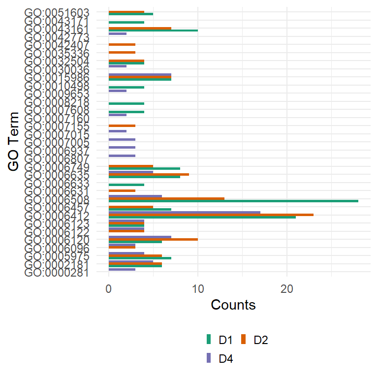

```r
BP_4ggplot <- melt(BP)
#BP_4ggplot$Function_short <- substr(BP_4ggplot$Function,1,15)
BP_4ggplot <- BP_4ggplot %>%
  mutate(Function_short = extract_goterm(Function))
ggplot(BP_4ggplot, aes(x=Function_short, y=value, fill=variable)) +
  geom_bar(stat='identity', position='dodge') +
  theme_minimal() +
  scale_fill_brewer(palette="Dark2") +
  theme(legend.position="bottom") +
  theme(legend.key.size = unit(0.15, 'cm')) +
  guides(fill=guide_legend(nrow=2, byrow=TRUE)) +
  ylab("Counts") +
  xlab("GO Term") +
  labs(fill = "") +
  coord_flip() +
  theme(legend.title = element_blank())
```

```r
################################# molecular function
t_BP <- as.data.frame(table(GO_1$Gene.Ontology..molecular.function.))
t_BP_sorted <- arrange(t_BP, desc(Freq))
t_BP_sorted_1 <- t_BP_sorted[c(1:20),]
t_BP <- as.data.frame(table(GO_2$Gene.Ontology..molecular.function.))
t_BP_sorted <- arrange(t_BP, desc(Freq))
t_BP_sorted_2 <- t_BP_sorted[c(1:20),]
t_BP <- as.data.frame(table(GO_3$Gene.Ontology..molecular.function.))
t_BP_sorted <- arrange(t_BP, desc(Freq))
t_BP_sorted_3 <- t_BP_sorted[c(1:20),]
BP <- merge(t_BP_sorted_1, t_BP_sorted_2,
            all = TRUE,
            by = "Var1")
BP <- merge(BP, t_BP_sorted_3, all = TRUE, by = "Var1")
results_comp <- c(results_comp,sum(is.na(BP$Freq.x) & !is.na(BP$Freq.y)))
results_comp <- c(results_comp,sum(rowSums(is.na(BP[2:3]))>1,na.rm = TRUE))
length_comp <- c(length_comp,length(BP[,1]),length(BP[,1]))
colnames(BP) <- c("Function", "D1: Phosphate buffer", "D1b: Carbonate buffer", "D2: Phosphate buffer with urea-triton X")

kable(BP)
```

| Function | D1: Phosphate buffer | D1b: Carbonate buffer | D2: Phosphate buffer with urea-triton X |
| --- | --- | --- | --- |
| actin filament binding [GO:0051015] | 7 | 7 | 4 |
| actin filament binding [GO:0051015]; ATP binding [GO:0005524]; microfilament motor activity [GO:0000146] | NA | NA | 2 |
| actin filament binding [GO:0051015]; calcium ion binding [GO:0005509]; calcium-dependent protein binding [GO:0048306] | NA | NA | 3 |
| actin monomer binding [GO:0003785] | NA | NA | 2 |
| ATP binding [GO:0005524]; ATP hydrolysis activity [GO:0016887]; ATP-dependent protein folding chaperone [GO:0140662]; unfolded protein binding [GO:0051082] | 6 | 5 | 2 |
| ATP binding [GO:0005524]; ATP hydrolysis activity [GO:0016887]; peptidase activity [GO:0008233]; proteasome-activating activity [GO:0036402] | 6 | 6 | NA |
| calcium ion binding [GO:0005509] | 13 | 10 | 4 |
| calcium ion binding [GO:0005509]; calcium-dependent phospholipid binding [GO:0005544] | NA | 4 | NA |
| chitin binding [GO:0008061] | 4 | NA | 4 |
| CoA-ligase activity [GO:0016405]; long-chain fatty acid-CoA ligase activity [GO:0004467]; monooxygenase activity [GO:0004497] | 4 | NA | NA |
| cysteine-type endopeptidase activity [GO:0004197] | 8 | 6 | NA |
| DNA binding [GO:0003677]; protein heterodimerization activity [GO:0046982]; structural constituent of chromatin [GO:0030527] | NA | 4 | 4 |
| glutathione transferase activity [GO:0004364] | 7 | 4 | NA |
| GTP binding [GO:0005525]; GTPase activity [GO:0003924] | 5 | 4 | NA |
| heme binding [GO:0020037]; iron ion binding [GO:0005506]; monooxygenase activity [GO:0004497]; oxidoreductase activity, acting on paired donors, with incorporation or reduction of molecular oxygen [GO… | NA | 9 | NA |
| hydrolase activity [GO:0016787] | 6 | NA | NA |
| large ribosomal subunit rRNA binding [GO:0070180]; structural constituent of ribosome [GO:0003735] | NA | NA | 3 |
| lipid transporter activity [GO:0005319] | NA | NA | 3 |
| metal ion binding [GO:0046872] | 4 | 4 | 4 |
| metallocarboxypeptidase activity [GO:0004181]; zinc ion binding [GO:0008270] | 4 | NA | NA |
| mRNA binding [GO:0003729] | NA | NA | 3 |
| odorant binding [GO:0005549] | 4 | NA | NA |
| oxidoreductase activity [GO:0016491] | 8 | 4 | NA |
| proton-transporting ATPase activity, rotational mechanism [GO:0046961] | 5 | 5 | 3 |
| proton transmembrane transporter activity [GO:0015078] | NA | 4 | 4 |
| RNA binding [GO:0003723] | 6 | 4 | NA |
| RNA binding [GO:0003723]; structural constituent of ribosome [GO:0003735] | 13 | 14 | 11 |
| rRNA binding [GO:0019843]; structural constituent of ribosome [GO:0003735] | NA | NA | 3 |
| serine-type endopeptidase activity [GO:0004252] | 12 | 6 | 3 |
| structural constituent of chitin-based larval cuticle [GO:0008010] | NA | 13 | 21 |
| structural constituent of ribosome [GO:0003735] | 25 | 23 | 17 |
| structural molecule activity [GO:0005198] | 6 | 5 | NA |
| structural constituent of cuticle [GO:0042302] | NA | NA | 12 |

```r
kable(subset(BP[,1], is.na(BP[,3]) == TRUE & !is.na(BP[,2]) == TRUE))
```

| x |
| --- |
| chitin binding [GO:0008061] |
| CoA-ligase activity [GO:0016405]; long-chain fatty acid-CoA ligase activity [GO:0004467]; monooxygenase activity [GO:0004497] |
| hydrolase activity [GO:0016787] |
| metallocarboxypeptidase activity [GO:0004181]; zinc ion binding [GO:0008270] |
| odorant binding [GO:0005549] |

```r
kable(subset(BP[,1], is.na(BP[,2]) == TRUE & !is.na(BP[,3]) == TRUE))
```

| x |
| --- |
| calcium ion binding [GO:0005509]; calcium-dependent phospholipid binding [GO:0005544] |
| DNA binding [GO:0003677]; protein heterodimerization activity [GO:0046982]; structural constituent of chromatin [GO:0030527] |
| heme binding [GO:0020037]; iron ion binding [GO:0005506]; monooxygenase activity [GO:0004497]; oxidoreductase activity, acting on paired donors, with incorporation or reduction of molecular oxygen [GO… |
| proton transmembrane transporter activity [GO:0015078] |
| structural constituent of chitin-based larval cuticle [GO:0008010] |

```r
kable(subset(BP[,1], is.na(BP[,4]) == TRUE & !is.na(BP[,3]) == TRUE))
```

| x |
| --- |
| ATP binding [GO:0005524]; ATP hydrolysis activity [GO:0016887]; peptidase activity [GO:0008233]; proteasome-activating activity [GO:0036402] |
| calcium ion binding [GO:0005509]; calcium-dependent phospholipid binding [GO:0005544] |
| cysteine-type endopeptidase activity [GO:0004197] |
| glutathione transferase activity [GO:0004364] |
| GTP binding [GO:0005525]; GTPase activity [GO:0003924] |
| heme binding [GO:0020037]; iron ion binding [GO:0005506]; monooxygenase activity [GO:0004497]; oxidoreductase activity, acting on paired donors, with incorporation or reduction of molecular oxygen [GO… |
| oxidoreductase activity [GO:0016491] |
| RNA binding [GO:0003723] |
| structural molecule activity [GO:0005198] |

```r
kable(subset(BP[,1], is.na(BP[,3]) == TRUE & !is.na(BP[,4]) == TRUE))
```

| x |
| --- |
| actin filament binding [GO:0051015]; ATP binding [GO:0005524]; microfilament motor activity [GO:0000146] |
| actin filament binding [GO:0051015]; calcium ion binding [GO:0005509]; calcium-dependent protein binding [GO:0048306] |
| actin monomer binding [GO:0003785] |
| chitin binding [GO:0008061] |
| large ribosomal subunit rRNA binding [GO:0070180]; structural constituent of ribosome [GO:0003735] |
| lipid transporter activity [GO:0005319] |
| mRNA binding [GO:0003729] |
| rRNA binding [GO:0019843]; structural constituent of ribosome [GO:0003735] |
| structural constituent of cuticle [GO:0042302] |

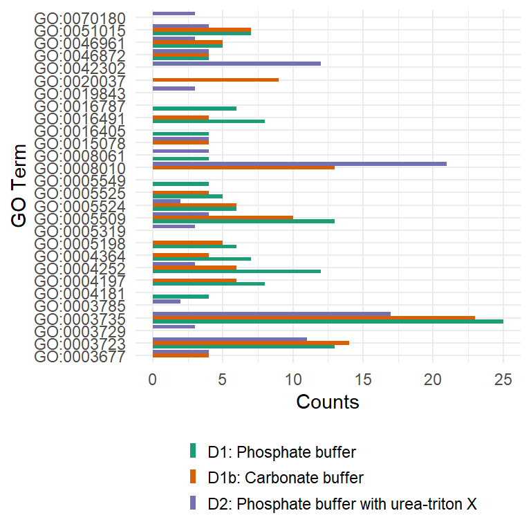

```r
BP_4ggplot <- melt(BP)
#BP_4ggplot$Function_short <- substr(BP_4ggplot$Function,1,15)
BP_4ggplot <- BP_4ggplot %>%
  mutate(Function_short = extract_goterm(Function))
ggplot(BP_4ggplot, aes(x=Function_short, y=value, fill=variable)) +
  geom_bar(stat='identity', position='dodge') +
  theme_minimal() +
  scale_fill_brewer(palette="Dark2") +
  theme(legend.position="bottom") +
  theme(legend.key.size = unit(0.15, 'cm')) +
  guides(fill=guide_legend(nrow=3, byrow=TRUE)) +
  ylab("Counts") +
  xlab("GO Term") +
  labs(fill = "") +
  coord_flip() +
  theme(legend.title = element_blank())
```

```r
################################# cellular.component
t_BP <- as.data.frame(table(GO_1$Gene.Ontology..cellular.component.))
t_BP_sorted <- arrange(t_BP, desc(Freq))
t_BP_sorted_1 <- t_BP_sorted[c(1:20),]
t_BP <- as.data.frame(table(GO_2$Gene.Ontology..cellular.component.))
t_BP_sorted <- arrange(t_BP, desc(Freq))
t_BP_sorted_2 <- t_BP_sorted[c(1:20),]
t_BP <- as.data.frame(table(GO_3$Gene.Ontology..cellular.component.))
t_BP_sorted <- arrange(t_BP, desc(Freq))
t_BP_sorted_3 <- t_BP_sorted[c(1:20),]
BP <- merge(t_BP_sorted_1, t_BP_sorted_2,
            all = TRUE,
            by = "Var1")
BP <- merge(BP, t_BP_sorted_3, all = TRUE, by = "Var1")
colnames(BP) <- c("Function", "D1","D2","D4")
kable(BP)
```

| Function | D1 | D2 | D4 |
| --- | --- | --- | --- |
| chaperonin-containing T-complex [GO:0005832] | 4 | NA | NA |
| chitin-based extracellular matrix [GO:0062129] | 4 | 13 | 21 |
| cytoplasm [GO:0005737] | 72 | 47 | 16 |
| cytoplasm [GO:0005737]; nucleus [GO:0005634] | 7 | 5 | NA |
| cytosol [GO:0005829] | 35 | 21 | 10 |
| cytosol [GO:0005829]; nucleus [GO:0005634] | 5 | NA | NA |
| cytosolic large ribosomal subunit [GO:0022625] | 22 | 23 | 15 |
| cytosolic small ribosomal subunit [GO:0022627] | 10 | 10 | 11 |
| endoplasmic reticulum membrane [GO:0005789] | NA | 6 | 3 |
| extracellular region [GO:0005576] | 14 | 12 | 15 |
| extracellular space [GO:0005615] | 13 | 9 | 3 |
| extracellular space [GO:0005615]; lysosome [GO:0005764] | 11 | 7 | NA |
| membrane [GO:0016020] | 15 | 29 | 20 |
| membrane [GO:0016020]; mitochondrion [GO:0005739] | NA | 5 | NA |
| mitochondrial inner membrane [GO:0005743] | NA | 7 | 6 |
| mitochondrial matrix [GO:0005759] | 7 | NA | NA |
| mitochondrial respiratory chain complex I [GO:0005747] | 9 | 19 | 14 |
| mitochondrial respiratory chain complex III [GO:0005750] | NA | NA | 4 |
| mitochondrial respiratory chain complex IV [GO:0005751] | 5 | 5 | 5 |
| mitochondrion [GO:0005739] | 32 | 31 | 12 |
| mitochondrion [GO:0005739]; peroxisome [GO:0005777] | 6 | NA | NA |
| nucleosome [GO:0000786]; nucleus [GO:0005634] | NA | NA | 4 |
| nucleus [GO:0005634] | 8 | 6 | 4 |
| peroxisome [GO:0005777] | 10 | 6 | NA |
| plasma membrane [GO:0005886] | NA | 6 | 5 |
| ribonucleoprotein complex [GO:1990904]; ribosome [GO:0005840] | 5 | 5 | 5 |
| troponin complex [GO:0005861] | NA | NA | 5 |
| extracellular matrix [GO:0031012] | NA | NA | 12 |

```r
kable(subset(BP[,1], is.na(BP[,3]) == TRUE & !is.na(BP[,2]) == TRUE))
```

| x |
| --- |
| chaperonin-containing T-complex [GO:0005832] |
| cytosol [GO:0005829]; nucleus [GO:0005634] |
| mitochondrial matrix [GO:0005759] |
| mitochondrion [GO:0005739]; peroxisome [GO:0005777] |

```r
kable(subset(BP[,1], is.na(BP[,2]) == TRUE & !is.na(BP[,3]) == TRUE))
```

| x |
| --- |
| endoplasmic reticulum membrane [GO:0005789] |
| membrane [GO:0016020]; mitochondrion [GO:0005739] |
| mitochondrial inner membrane [GO:0005743] |
| plasma membrane [GO:0005886] |

```r
kable(subset(BP[,1], is.na(BP[,4]) == TRUE & !is.na(BP[,3]) == TRUE))
```

| x |
| --- |
| cytoplasm [GO:0005737]; nucleus [GO:0005634] |
| extracellular space [GO:0005615]; lysosome [GO:0005764] |
| membrane [GO:0016020]; mitochondrion [GO:0005739] |
| peroxisome [GO:0005777] |

```r
kable(subset(BP[,1], is.na(BP[,3]) == TRUE & !is.na(BP[,4]) == TRUE))
```

| x |
| --- |
| mitochondrial respiratory chain complex III [GO:0005750] |
| nucleosome [GO:0000786]; nucleus [GO:0005634] |
| troponin complex [GO:0005861] |
| extracellular matrix [GO:0031012] |

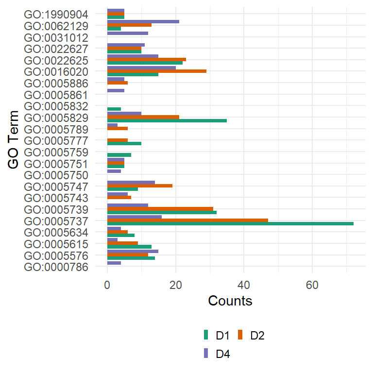

```r
BP_4ggplot <- melt(BP)
#BP_4ggplot$Function_short <- substr(BP_4ggplot$Function,1,15)
BP_4ggplot <- BP_4ggplot %>%
  mutate(Function_short = extract_goterm(Function))
ggplot(BP_4ggplot, aes(x=Function_short, y=value, fill=variable)) +
  geom_bar(stat='identity', position='dodge') +
  theme_minimal() +
  scale_fill_brewer(palette="Dark2") +
  theme(legend.position="bottom") +
  theme(legend.key.size = unit(0.15, 'cm')) +
  guides(fill=guide_legend(nrow=2, byrow=TRUE)) +
  ylab("Counts") +
  xlab("GO Term") +
  labs(fill = "") +
  coord_flip() +
  theme(legend.title = element_blank())
```

## 4.3 C

```r
# D1-D2 comparison
D1_raw <- readRDS(file = "results_v002/results_run1_mqpar_extracts_2gether_E4_D1_a-j_LFQ_combined_txt_proteinGroups.txt_Unique.RDS")
D1_raw <- D1_raw[[1]]
D1 <- dplyr::select(D1_raw, contains("Pool"))
D1 <- apply(D1, 1, any)
#D1 <- as.data.frame(cbind(D1, D1_raw$FASTA))
fasta <- c()
for (i in 1:length(D1_raw$FASTA)){
  tmp <- strsplit(D1_raw$FASTA[i],split='\\|')[[1]][2]
  fasta <- c(fasta,tmp)
}
D1 <- as.data.frame(cbind(D1, fasta))
D2_raw <- readRDS(file = "results_v002/results_run1_mqpar_extracts_2gether_D2_LFQ_combined_txt_proteinGroups.txt_Unique.RDS")
D2_raw <- D2_raw[[1]]
D2 <- dplyr::select(D2_raw, contains("Gesamt"))
D2 <- apply(D2, 1, any)
fasta <- c()
for (i in 1:length(D2_raw$FASTA)){
  tmp <- strsplit(D2_raw$FASTA[i],split='\\|')[[1]][2]
  fasta <- c(fasta,tmp)
}
#D2 <- as.data.frame(cbind(D2, D2_raw$FASTA))
D2 <- as.data.frame(cbind(D2, fasta))
D1_D2_comparison  <- merge(D1, D2,
                           all = TRUE,
                           by = "fasta")
D1_D2_comparison$comb <- apply(D1_D2_comparison[,c(2:3)], 1, any)
```

[output not shown]

[output cut: 5425 more lines]

[output not shown]

```r
#E5
data <- readRDS("./27_20230201_FH/results/D5_extracts_Razor.RDS")
data <- data[[1]]
b <- dplyr::select(data, contains("_b"))
b <- b[,-c(5:6)]
b <- as.data.frame(apply(b, 1, any))
fasta <- c()
for (i in 1:length(data$FASTA)){
  tmp <- strsplit(data$FASTA[i],split='\\|')[[1]][2]
  fasta <- c(fasta,tmp)
}
b$fasta <- fasta
colnames(b) <- c("b","fasta")

#merge with D5
D1_D2_D5_comparison  <- merge(D1_D2_comparison[,c(1,4)],b,
                              all = TRUE,
                              by = "fasta")
colnames(D1_D2_D5_comparison) <- c("fasta","E4","E5")

D1_D2_D5_comparison$D1 <- as.logical(D1_D2_D5_comparison$E4)
D1_D2_D5_comparison$D2 <- as.logical(D1_D2_D5_comparison$E5)

D1 <- D1_D2_D5_comparison$fasta[D1_D2_D5_comparison$D1]
D1 <- D1[!is.na(D1)]
D2 <- D1_D2_D5_comparison$fasta[D1_D2_D5_comparison$D2]
D2 <- D2[!is.na(D2)]
#D1_uni <- GetProteinGOInfo(D1)
#saveRDS(D1_uni,"./go_terms/graph2_E4_uni.RDS")
GO_1 <- readRDS("./go_terms/graph2_E4_uni.RDS")
#D2_uni <- GetProteinGOInfo(D2)
#saveRDS(D2_uni,"./go_terms/graph2_E5_uni.RDS")
GO_2 <- readRDS("./go_terms/graph2_E5_uni.RDS")

################################# Biological process
t_BP <- as.data.frame(table(GO_1$Gene.Ontology..biological.process.))
t_BP_sorted <- arrange(t_BP, desc(Freq))
t_BP_sorted_1 <- t_BP_sorted[c(1:20),]
t_BP <- as.data.frame(table(GO_2$Gene.Ontology..biological.process.))
t_BP_sorted <- arrange(t_BP, desc(Freq))
t_BP_sorted_2 <- t_BP_sorted[c(1:20),]
#t_BP <- as.data.frame(table(GO[[3]]$Gene.ontology..biological.process.))
#t_BP_sorted <- arrange(t_BP, desc(Freq))
#t_BP_sorted_3 <- t_BP_sorted[c(1:20),]
BP <- merge(t_BP_sorted_1, t_BP_sorted_2,
            all = TRUE,
            by = "Var1")
#BP <- merge(BP, t_BP_sorted_3, all = TRUE, by = "Var1")


colnames(BP) <- c("Function", "E4","E5")

kable(BP)
```

| Function | E4 | E5 |
| --- | --- | --- |
| actin cytoskeleton organization [GO:0030036] | 3 | NA |
| bioluminescence [GO:0008218] | NA | 5 |
| bioluminescence [GO:0008218]; fatty-acyl-CoA biosynthetic process [GO:0046949]; long-chain fatty acid metabolic process [GO:0001676] | NA | 4 |
| carbohydrate metabolic process [GO:0005975] | 7 | 8 |
| carbohydrate metabolic process [GO:0005975]; chitin catabolic process [GO:0006032] | 6 | 5 |
| cell adhesion [GO:0007155] | NA | 4 |
| cytoplasmic translation [GO:0002181] | 6 | 6 |
| fatty acid beta-oxidation [GO:0006635] | 9 | 9 |
| fatty acid biosynthetic process [GO:0006633] | 4 | 4 |
| glutathione metabolic process [GO:0006749] | 7 | 8 |
| mitochondrial electron transport, cytochrome c to oxygen [GO:0006123] | 4 | 4 |
| mitochondrial electron transport, NADH to ubiquinone [GO:0006120] | 6 | 10 |
| mitochondrial electron transport, ubiquinol to cytochrome c [GO:0006122] | 5 | 4 |
| multicellular organism reproduction [GO:0032504] | 5 | 5 |
| peptide catabolic process [GO:0043171]; proteolysis [GO:0006508] | 4 | 4 |
| proteasomal protein catabolic process [GO:0010498] | 4 | NA |
| proteasome-mediated ubiquitin-dependent protein catabolic process [GO:0043161] | 9 | 10 |
| protein folding [GO:0006457] | 7 | 7 |
| proteolysis [GO:0006508] | 23 | 31 |
| proteolysis involved in protein catabolic process [GO:0051603]; regulation of catalytic activity [GO:0050790] | 4 | 5 |
| proton motive force-driven ATP synthesis [GO:0015986] | 7 | 7 |
| translation [GO:0006412] | 24 | 25 |
| transmembrane transport [GO:0055085] | 4 | NA |

```r
kable(BP[is.na(BP[,3])==TRUE,1])
```

| x |
| --- |
| actin cytoskeleton organization [GO:0030036] |
| proteasomal protein catabolic process [GO:0010498] |
| transmembrane transport [GO:0055085] |

```r
kable(BP[is.na(BP[,2])==TRUE,1])
```

| x |
| --- |
| bioluminescence [GO:0008218] |
| bioluminescence [GO:0008218]; fatty-acyl-CoA biosynthetic process [GO:0046949]; long-chain fatty acid metabolic process [GO:0001676] |
| cell adhesion [GO:0007155] |

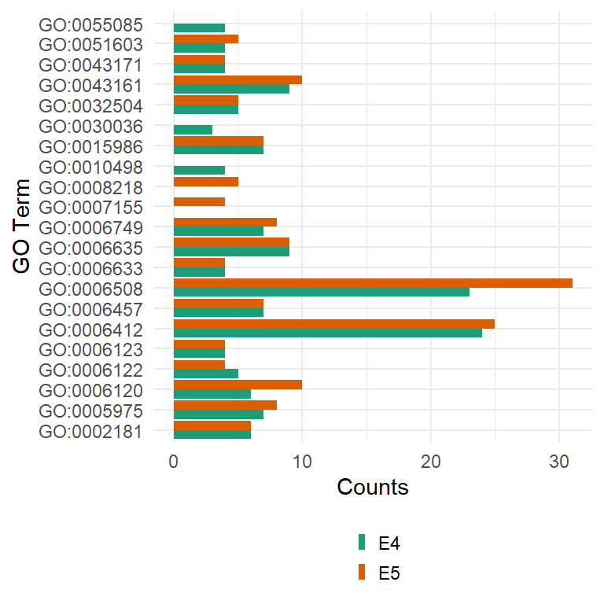

```r
BP_4ggplot <- melt(BP)
#BP_4ggplot$Function_short <- substr(BP_4ggplot$Function,1,15)
BP_4ggplot <- BP_4ggplot %>%
  mutate(Function_short = extract_goterm(Function))
ggplot(BP_4ggplot, aes(x=Function_short, y=value, fill=variable)) +
  geom_bar(stat='identity', position='dodge') +
  theme_minimal() +
  scale_fill_brewer(palette="Dark2") +
  theme(legend.position="bottom") +
  theme(legend.key.size = unit(0.15, 'cm')) +
  guides(fill=guide_legend(nrow=2, byrow=TRUE)) +
  ylab("Counts") +
  xlab("GO Term") +
  labs(fill = "") +
  coord_flip() +
  theme(legend.title = element_blank())
```

```r
################################# molecular function
t_BP <- as.data.frame(table(GO_1$Gene.Ontology..molecular.function.))
t_BP_sorted <- arrange(t_BP, desc(Freq))
t_BP_sorted_1 <- t_BP_sorted[c(1:20),]
t_BP <- as.data.frame(table(GO_2$Gene.Ontology..molecular.function.))
t_BP_sorted <- arrange(t_BP, desc(Freq))
t_BP_sorted_2 <- t_BP_sorted[c(1:20),]
#t_BP <- as.data.frame(table(GO_3$Gene.Ontology..molecular.function.))
#t_BP_sorted <- arrange(t_BP, desc(Freq))
#t_BP_sorted_3 <- t_BP_sorted[c(1:20),]
BP <- merge(t_BP_sorted_1, t_BP_sorted_2,
            all = TRUE,
            by = "Var1")
#BP <- merge(BP, t_BP_sorted_3, all = TRUE, by = "Var1")
results_comp <- c(results_comp,sum(is.na(BP[2])))
length_comp <- c(length_comp, length(BP[,1]))
colnames(BP) <- c("Function", "2D","3D")
kable(BP)
```

| Function | 2D | 3D |
| --- | --- | --- |
| actin filament binding [GO:0051015] | 7 | 9 |
| ATP binding [GO:0005524]; ATP hydrolysis activity [GO:0016887]; ATP-dependent protein folding chaperone [GO:0140662]; unfolded protein binding [GO:0051082] | 7 | 6 |
| ATP binding [GO:0005524]; ATP hydrolysis activity [GO:0016887]; peptidase activity [GO:0008233]; proteasome-activating activity [GO:0036402] | 6 | 6 |
| calcium ion binding [GO:0005509] | 12 | 14 |
| calcium ion binding [GO:0005509]; calcium-dependent phospholipid binding [GO:0005544] | NA | 4 |
| chitin binding [GO:0008061] | NA | 5 |
| chitin binding [GO:0008061]; chitinase activity [GO:0004568] | 4 | NA |
| cysteine-type endopeptidase activity [GO:0004197] | 5 | 8 |
| glutathione transferase activity [GO:0004364] | 6 | 7 |
| GTP binding [GO:0005525]; GTPase activity [GO:0003924] | 6 | 6 |
| heme binding [GO:0020037]; iron ion binding [GO:0005506]; monooxygenase activity [GO:0004497]; oxidoreductase activity, acting on paired donors, with incorporation or reduction of molecular oxygen [GO… | 13 | 9 |
| hydrolase activity [GO:0016787] | 8 | 7 |
| metal ion binding [GO:0046872] | 4 | NA |
| oxidoreductase activity [GO:0016491] | 7 | 9 |
| proton-transporting ATPase activity, rotational mechanism [GO:0046961] | 5 | 5 |
| proton transmembrane transporter activity [GO:0015078] | 4 | NA |
| RNA binding [GO:0003723] | NA | 8 |
| RNA binding [GO:0003723]; structural constituent of ribosome [GO:0003735] | 16 | 15 |
| serine-type endopeptidase activity [GO:0004252] | 9 | 13 |
| structural constituent of chitin-based larval cuticle [GO:0008010] | 13 | 22 |
| structural constituent of cuticle [GO:0042302] | 8 | 13 |
| structural constituent of ribosome [GO:0003735] | 26 | 25 |
| structural molecule activity [GO:0005198] | 6 | 7 |

```r
kable(BP[is.na(BP[,3])==TRUE,1])
```

| x |
| --- |
| chitin binding [GO:0008061]; chitinase activity [GO:0004568] |
| metal ion binding [GO:0046872] |
| proton transmembrane transporter activity [GO:0015078] |

```r
kable(BP[is.na(BP[,2])==TRUE,1])
```

| x |
| --- |
| calcium ion binding [GO:0005509]; calcium-dependent phospholipid binding [GO:0005544] |
| chitin binding [GO:0008061] |
| RNA binding [GO:0003723] |

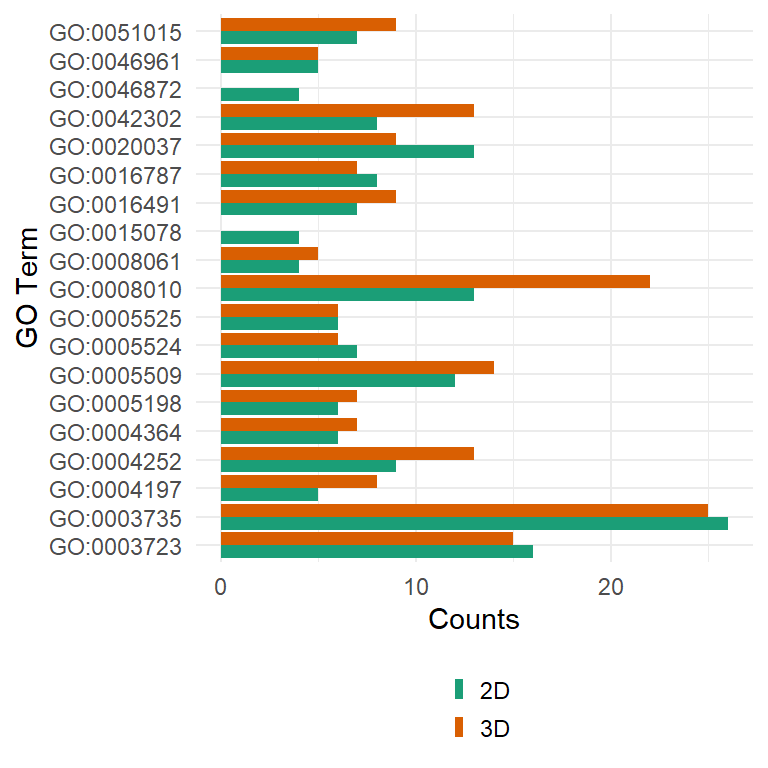

```r
BP_4ggplot <- melt(BP)
#BP_4ggplot$Function_short <- substr(BP_4ggplot$Function,1,15)
BP_4ggplot <- BP_4ggplot %>%
  mutate(Function_short = extract_goterm(Function))
ggplot(BP_4ggplot, aes(x=Function_short, y=value, fill=variable)) +
  geom_bar(stat='identity', position='dodge') +
  theme_minimal() +
  scale_fill_brewer(palette="Dark2") +
  theme(legend.position="bottom") +
  theme(legend.key.size = unit(0.15, 'cm')) +
  guides(fill=guide_legend(nrow=2, byrow=TRUE)) +
  ylab("Counts") +
  xlab("GO Term") +
  labs(fill = "") +
  coord_flip() +
  theme(legend.title = element_blank())
```

```r
################################# cellular.component
t_BP <- as.data.frame(table(GO_1$Gene.Ontology..cellular.component.))
t_BP_sorted <- arrange(t_BP, desc(Freq))
t_BP_sorted_1 <- t_BP_sorted[c(1:20),]
t_BP <- as.data.frame(table(GO_2$Gene.Ontology..cellular.component.))
t_BP_sorted <- arrange(t_BP, desc(Freq))
t_BP_sorted_2 <- t_BP_sorted[c(1:20),]
#t_BP <- as.data.frame(table(GO_3$Gene.Ontology..cellular.component.))
#t_BP_sorted <- arrange(t_BP, desc(Freq))
#t_BP_sorted_3 <- t_BP_sorted[c(1:20),]
BP <- merge(t_BP_sorted_1, t_BP_sorted_2,
            all = TRUE,
            by = "Var1")
#BP <- merge(BP, t_BP_sorted_3, all = TRUE, by = "Var1")

colnames(BP) <- c("Function", "E4","E5")
kable(BP)
```

| Function | E4 | E5 |
| --- | --- | --- |
| chitin-based extracellular matrix [GO:0062129] | 13 | 22 |
| cytoplasm [GO:0005737] | 66 | 73 |
| cytoplasm [GO:0005737]; nucleus [GO:0005634] | 8 | 8 |
| cytosol [GO:0005829] | 29 | 37 |
| cytosolic large ribosomal subunit [GO:0022625] | 26 | 24 |
| cytosolic small ribosomal subunit [GO:0022627] | 12 | 12 |
| endoplasmic reticulum [GO:0005783]; membrane [GO:0016020] | 5 | NA |
| endoplasmic reticulum membrane [GO:0005789] | 9 | 9 |
| extracellular matrix [GO:0031012] | 8 | 13 |
| extracellular region [GO:0005576] | 15 | 20 |
| extracellular space [GO:0005615] | 14 | 15 |
| extracellular space [GO:0005615]; lysosome [GO:0005764] | 8 | 11 |
| membrane [GO:0016020] | 42 | 43 |
| mitochondrial inner membrane [GO:0005743] | 8 | 7 |
| mitochondrial matrix [GO:0005759] | 6 | 7 |
| mitochondrial respiratory chain complex I [GO:0005747] | 12 | 19 |
| mitochondrion [GO:0005739] | 35 | 34 |
| mitochondrion [GO:0005739]; peroxisome [GO:0005777] | NA | 6 |
| nucleus [GO:0005634] | 9 | 9 |
| peroxisome [GO:0005777] | 9 | 11 |
| plasma membrane [GO:0005886] | 8 | 11 |

```r
kable(BP[is.na(BP[,3])==TRUE,1])
```

| x |
| --- |
| endoplasmic reticulum [GO:0005783]; membrane [GO:0016020] |

```r
kable(BP[is.na(BP[,2])==TRUE,1])
```

| x |
| --- |
| mitochondrion [GO:0005739]; peroxisome [GO:0005777] |

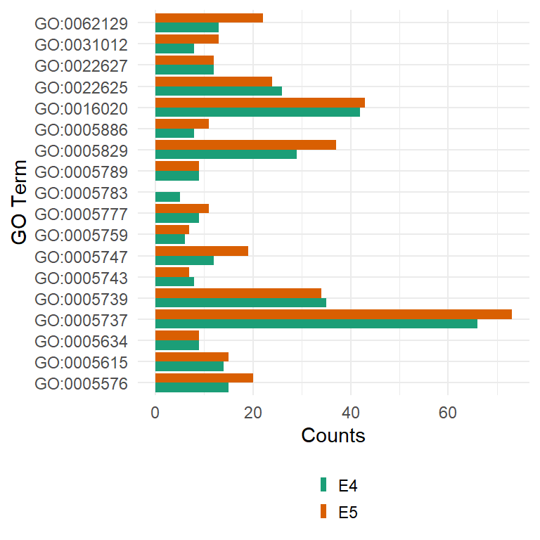

```r
BP_4ggplot <- melt(BP)
#BP_4ggplot$Function_short <- substr(BP_4ggplot$Function,1,15)
BP_4ggplot <- BP_4ggplot %>%
  mutate(Function_short = extract_goterm(Function))
ggplot(BP_4ggplot, aes(x=Function_short, y=value, fill=variable)) +
  geom_bar(stat='identity', position='dodge') +
  theme_minimal() +
  scale_fill_brewer(palette="Dark2") +
  theme(legend.position="bottom") +
  theme(legend.key.size = unit(0.15, 'cm')) +
  guides(fill=guide_legend(nrow=2, byrow=TRUE)) +
  ylab("Counts") +
  xlab("GO Term") +
  labs(fill = "") +
  coord_flip() +
  theme(legend.title = element_blank())
```

# 5 Grafik 3

## 5.1 A

```r
############## B
data <- readRDS(file = "results_v002/results_run1_mqpar_extracts_2gether_E4_D1_B_LFQ_combined_txt_proteinGroups.txt_Unique.RDS")
data <- data[[1]]
data_sub <- dplyr::select(data, contains("Pool_G"))
#get rid of FALSE values
B <- data_sub*1
B[B==0] <- NA
ind <- apply(B, 1, function(x) all(is.na(x)))


############AF
data <- readRDS(file = "results_v002/results_run1_mqpar_extracts_2gether_E4_D1_AF_TF_LFQ_combined_txt_proteinGroups.txt_Unique.RDS")
data <- data[[1]]
data_sub <- dplyr::select(data, contains("Pool_AF"))
#get rid of FALSE values
AF <- data_sub*1
AF[AF==0] <- NA
ind <- apply(AF, 1, function(x) all(is.na(x)))

############TF
data <- readRDS(file = "results_v002/results_run1_mqpar_extracts_2gether_E4_D1_AF_TF_LFQ_combined_txt_proteinGroups.txt_Unique.RDS")
data <- data[[1]]
data_sub <- dplyr::select(data, contains("Pool_TF"))
#get rid of FALSE values
TF <- data_sub*1
TF[TF==0] <- NA
ind <- apply(TF, 1, function(x) all(is.na(x)))


## compare AF TF B poster
AF_TF_raw <- readRDS(file = "results_v002/results_run1_mqpar_extracts_2gether_E4_D1_AF_TF_LFQ_combined_txt_proteinGroups.txt_Unique.RDS")
AF_TF_raw <- AF_TF_raw[[1]]
AF <- dplyr::select(AF_TF_raw, contains("AF"))
AF <- apply(AF, 1, any)
fasta <- c()
for (i in 1:length(AF_TF_raw$FASTA)){
  tmp <- strsplit(AF_TF_raw$FASTA[i],split='\\|')[[1]][2]
  fasta <- c(fasta,tmp)
}
AF <- as.data.frame(cbind(AF, fasta))
TF <- dplyr::select(AF_TF_raw, contains("TF"))
TF <- apply(TF, 1, any)
TF <- as.data.frame(cbind(TF, fasta))
B_raw <- readRDS(file = "results_v002/results_run1_mqpar_extracts_2gether_E4_D1_B_LFQ_combined_txt_proteinGroups.txt_Unique.RDS")
B_raw <- B_raw[[1]]
B <- dplyr::select(B_raw, contains("Pool_G"))
B <- apply(B, 1, any)
fasta <- c()
for (i in 1:length(B_raw$FASTA)){
  tmp <- strsplit(B_raw$FASTA[i],split='\\|')[[1]][2]
  fasta <- c(fasta,tmp)
}
B <- as.data.frame(cbind(B, fasta))

AF_TF_B_comparison  <- merge(B, AF,
                             all = TRUE,
                             by = "fasta")
AF_TF_B_comparison <- merge(AF_TF_B_comparison, TF,
                            all = TRUE,
                            by = "fasta")

AF_TF_B_comparison$B <- as.logical(AF_TF_B_comparison$B)
AF_TF_B_comparison$AF <- as.logical(AF_TF_B_comparison$AF)
AF_TF_B_comparison$TF <- as.logical(AF_TF_B_comparison$TF)

B <- AF_TF_B_comparison$fasta[AF_TF_B_comparison$B]
B <- B[!is.na(B)]
AF <- AF_TF_B_comparison$fasta[AF_TF_B_comparison$AF]
AF <- AF[!is.na(AF)]
TF <- AF_TF_B_comparison$fasta[AF_TF_B_comparison$TF]
TF <- TF[!is.na(TF)]

#B <- GetProteinGOInfo(B)
#saveRDS(B,"./go_terms/graph3_A_B_uni.RDS")
GO_1 <- readRDS("./go_terms/graph3_A_B_uni.RDS")
#AF <- GetProteinGOInfo(AF)
#saveRDS(AF,"./go_terms/graph3_A_AF_uni.RDS")
GO_2 <- readRDS("./go_terms/graph3_A_AF_uni.RDS")
#TF <- GetProteinGOInfo(TF)
#saveRDS(TF,"./go_terms/graph3_A_TF_uni.RDS")
GO_3 <- readRDS("./go_terms/graph3_A_TF_uni.RDS")
################################# Biological process
t_BP <- as.data.frame(table(GO_1$Gene.Ontology..biological.process.))
t_BP_sorted <- arrange(t_BP, desc(Freq))
t_BP_sorted_1 <- t_BP_sorted[c(1:20),]
t_BP <- as.data.frame(table(GO_2$Gene.Ontology..biological.process.))
t_BP_sorted <- arrange(t_BP, desc(Freq))
t_BP_sorted_2 <- t_BP_sorted[c(1:20),]
t_BP <- as.data.frame(table(GO_3$Gene.Ontology..biological.process.))
t_BP_sorted <- arrange(t_BP, desc(Freq))
t_BP_sorted_3 <- t_BP_sorted[c(1:20),]
BP <- merge(t_BP_sorted_1, t_BP_sorted_2,
            all = TRUE,
            by = "Var1")
BP <- merge(BP, t_BP_sorted_3, all = TRUE, by = "Var1")


colnames(BP) <- c("Function", "B","AF","TF")
kable(BP)
```

| Function | B | AF | TF |
| --- | --- | --- | --- |
| anatomical structure morphogenesis [GO:0009653]; cell differentiation [GO:0030154]; protein phosphorylation [GO:0006468] | NA | 3 | NA |
| bioluminescence [GO:0008218]; fatty-acyl-CoA biosynthetic process [GO:0046949]; long-chain fatty acid metabolic process [GO:0001676] | 6 | NA | NA |
| carbohydrate metabolic process [GO:0005975] | 15 | 11 | 10 |
| carbohydrate metabolic process [GO:0005975]; chitin catabolic process [GO:0006032] | 10 | 6 | 6 |
| cytoplasmic translation [GO:0002181] | 6 | NA | 3 |
| dephosphorylation [GO:0016311] | 6 | NA | NA |
| fatty acid beta-oxidation [GO:0006635] | 12 | 9 | 8 |
| fatty acid biosynthetic process [GO:0006633] | 6 | 5 | 4 |
| fucose metabolic process [GO:0006004]; glycoside catabolic process [GO:0016139] | NA | 3 | 3 |
| glutathione metabolic process [GO:0006749] | 13 | 8 | 7 |
| glycolytic process [GO:0006096] | NA | 3 | 3 |
| glycoside catabolic process [GO:0016139]; lipid metabolic process [GO:0006629]; oligosaccharide metabolic process [GO:0009311] | NA | 3 | 3 |
| L-ascorbic acid biosynthetic process [GO:0019853] | 7 | 3 | 4 |
| lipid metabolic process [GO:0006629] | 6 | NA | NA |
| mannose metabolic process [GO:0006013] | NA | NA | 3 |
| mitochondrial electron transport, cytochrome c to oxygen [GO:0006123] | 5 | NA | NA |
| mitochondrial electron transport, NADH to ubiquinone [GO:0006120] | 9 | NA | NA |
| multicellular organism reproduction [GO:0032504] | 11 | NA | NA |
| negative regulation of peptidase activity [GO:0010466] | 11 | NA | NA |
| nitrogen compound metabolic process [GO:0006807] | 6 | NA | NA |
| peptide catabolic process [GO:0043171]; proteolysis [GO:0006508] | NA | 5 | 4 |
| proteasomal protein catabolic process [GO:0010498] | NA | 5 | 5 |
| proteasome-mediated ubiquitin-dependent protein catabolic process [GO:0043161] | 10 | 8 | 10 |
| protein folding [GO:0006457] | 10 | 6 | 6 |
| proteolysis [GO:0006508] | 61 | 26 | 28 |
| proteolysis involved in protein catabolic process [GO:0051603]; regulation of catalytic activity [GO:0050790] | NA | 5 | NA |
| proton motive force-driven ATP synthesis [GO:0015986] | 6 | 6 | 7 |
| sensory perception of smell [GO:0007608] | NA | 4 | 4 |
| translation [GO:0006412] | 35 | 15 | 24 |
| tricarboxylic acid cycle [GO:0006099] | NA | 4 | 4 |

```r
kable(subset(BP[,1], is.na(BP[,3]) == TRUE & !is.na(BP[,2]) == TRUE))
```

| x |
| --- |
| bioluminescence [GO:0008218]; fatty-acyl-CoA biosynthetic process [GO:0046949]; long-chain fatty acid metabolic process [GO:0001676] |
| cytoplasmic translation [GO:0002181] |
| dephosphorylation [GO:0016311] |
| lipid metabolic process [GO:0006629] |
| mitochondrial electron transport, cytochrome c to oxygen [GO:0006123] |
| mitochondrial electron transport, NADH to ubiquinone [GO:0006120] |
| multicellular organism reproduction [GO:0032504] |
| negative regulation of peptidase activity [GO:0010466] |
| nitrogen compound metabolic process [GO:0006807] |

```r
kable(subset(BP[,1], is.na(BP[,2]) == TRUE & !is.na(BP[,3]) == TRUE))
```

| x |
| --- |
| anatomical structure morphogenesis [GO:0009653]; cell differentiation [GO:0030154]; protein phosphorylation [GO:0006468] |
| fucose metabolic process [GO:0006004]; glycoside catabolic process [GO:0016139] |
| glycolytic process [GO:0006096] |
| glycoside catabolic process [GO:0016139]; lipid metabolic process [GO:0006629]; oligosaccharide metabolic process [GO:0009311] |
| peptide catabolic process [GO:0043171]; proteolysis [GO:0006508] |
| proteasomal protein catabolic process [GO:0010498] |
| proteolysis involved in protein catabolic process [GO:0051603]; regulation of catalytic activity [GO:0050790] |
| sensory perception of smell [GO:0007608] |
| tricarboxylic acid cycle [GO:0006099] |

```r
kable(subset(BP[,1], is.na(BP[,4]) == TRUE & !is.na(BP[,3]) == TRUE))
```

| x |
| --- |
| anatomical structure morphogenesis [GO:0009653]; cell differentiation [GO:0030154]; protein phosphorylation [GO:0006468] |
| proteolysis involved in protein catabolic process [GO:0051603]; regulation of catalytic activity [GO:0050790] |

```r
kable(subset(BP[,1], is.na(BP[,3]) == TRUE & !is.na(BP[,4]) == TRUE))
```

| x |
| --- |
| cytoplasmic translation [GO:0002181] |
| mannose metabolic process [GO:0006013] |

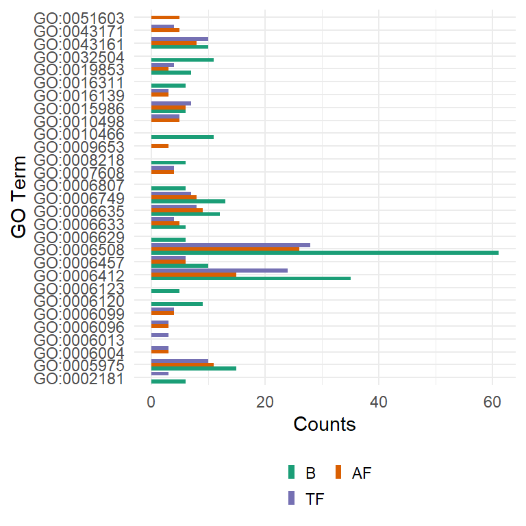

```r
BP_4ggplot <- melt(BP)
#BP_4ggplot$Function_short <- substr(BP_4ggplot$Function,1,15)
BP_4ggplot <- BP_4ggplot %>%
  mutate(Function_short = extract_goterm(Function))
ggplot(BP_4ggplot, aes(x=Function_short, y=value, fill=variable)) +
  geom_bar(stat='identity', position='dodge') +
  theme_minimal() +
  scale_fill_brewer(palette="Dark2") +
  theme(legend.position="bottom") +
  theme(legend.key.size = unit(0.15, 'cm')) +
  guides(fill=guide_legend(nrow=2, byrow=TRUE)) +
  ylab("Counts") +
  xlab("GO Term") +
  labs(fill = "") +
  coord_flip() +
  theme(legend.title = element_blank())
```

```r
################################# molecular function
t_BP <- as.data.frame(table(GO_1$Gene.Ontology..molecular.function.))
t_BP_sorted <- arrange(t_BP, desc(Freq))
t_BP_sorted_1 <- t_BP_sorted[c(1:20),]
t_BP <- as.data.frame(table(GO_2$Gene.Ontology..molecular.function.))
t_BP_sorted <- arrange(t_BP, desc(Freq))
t_BP_sorted_2 <- t_BP_sorted[c(1:20),]
t_BP <- as.data.frame(table(GO_3$Gene.Ontology..molecular.function.))
t_BP_sorted <- arrange(t_BP, desc(Freq))
t_BP_sorted_3 <- t_BP_sorted[c(1:20),]
BP <- merge(t_BP_sorted_1, t_BP_sorted_2,
            all = TRUE,
            by = "Var1")
BP <- merge(BP, t_BP_sorted_3, all = TRUE, by = "Var1")
results_comp <- c(results_comp,sum(is.na(BP[2])))
results_comp <- c(results_comp,sum(rowSums(is.na(BP[2:3]))>1,na.rm = TRUE))
length_comp <- c(length_comp, length(BP[,1]), length(BP[,1]))

colnames(BP) <- c("Function", "D1-electrophoretic fractionation","D1-low MW SEC fractionation","D1-high MW SEC fractionation")
kable(BP)
```

| Function | D1-electrophoretic fractionation | D1-low MW SEC fractionation | D1-high MW SEC fractionation |
| --- | --- | --- | --- |
| actin binding [GO:0003779] | NA | 3 | NA |
| actin filament binding [GO:0051015] | 11 | 5 | 4 |
| alpha-galactosidase activity [GO:0004557] | NA | 3 | 3 |
| alpha-L-fucosidase activity [GO:0004560] | NA | 3 | 3 |
| alpha-mannosidase activity [GO:0004559]; carbohydrate binding [GO:0030246]; metal ion binding [GO:0046872] | NA | 3 | 3 |
| ATP binding [GO:0005524]; ATP hydrolysis activity [GO:0016887]; ATP-dependent protein folding chaperone [GO:0140662]; unfolded protein binding [GO:0051082] | 6 | 5 | 4 |
| ATP binding [GO:0005524]; ATP hydrolysis activity [GO:0016887]; peptidase activity [GO:0008233]; proteasome-activating activity [GO:0036402] | 6 | 6 | 6 |
| beta-glucosidase activity [GO:0008422] | NA | NA | 3 |
| calcium ion binding [GO:0005509] | 13 | 7 | 6 |
| chitin binding [GO:0008061] | NA | 4 | NA |
| chitin binding [GO:0008061]; chitinase activity [GO:0004568] | 8 | 4 | 4 |
| cysteine-type endopeptidase activity [GO:0004197] | 9 | 7 | 5 |
| glutathione transferase activity [GO:0004364] | 11 | 6 | 5 |
| GTP binding [GO:0005525]; GTPase activity [GO:0003924] | 18 | NA | NA |
| heme binding [GO:0020037]; iron ion binding [GO:0005506]; monooxygenase activity [GO:0004497]; oxidoreductase activity, acting on paired donors, with incorporation or reduction of molecular oxygen [GO… | 13 | NA | NA |
| hydrolase activity [GO:0016787] | 16 | 7 | 7 |
| mRNA binding [GO:0003729] | 7 | NA | NA |
| odorant binding [GO:0005549] | NA | 4 | 4 |
| oxidoreductase activity [GO:0016491] | 14 | 5 | 4 |
| phosphatase activity [GO:0016791] | 7 | NA | NA |
| proton-transporting ATPase activity, rotational mechanism [GO:0046961] | 7 | NA | NA |
| proton transmembrane transporter activity [GO:0015078] | NA | NA | 4 |
| RNA binding [GO:0003723] | 15 | 4 | 4 |
| RNA binding [GO:0003723]; structural constituent of ribosome [GO:0003735] | 18 | 11 | 15 |
| serine-type endopeptidase activity [GO:0004252] | 40 | 14 | 11 |
| serine-type endopeptidase inhibitor activity [GO:0004867] | 11 | NA | NA |
| structural constituent of chitin-based larval cuticle [GO:0008010] | NA | 4 | NA |
| structural constituent of ribosome [GO:0003735] | 46 | 16 | 29 |
| structural molecule activity [GO:0005198] | 7 | NA | 4 |

```r
kable(subset(BP[,1], is.na(BP[,3]) == TRUE & !is.na(BP[,2]) == TRUE))
```

| x |
| --- |
| GTP binding [GO:0005525]; GTPase activity [GO:0003924] |
| heme binding [GO:0020037]; iron ion binding [GO:0005506]; monooxygenase activity [GO:0004497]; oxidoreductase activity, acting on paired donors, with incorporation or reduction of molecular oxygen [GO… |
| mRNA binding [GO:0003729] |
| phosphatase activity [GO:0016791] |
| proton-transporting ATPase activity, rotational mechanism [GO:0046961] |
| serine-type endopeptidase inhibitor activity [GO:0004867] |
| structural molecule activity [GO:0005198] |

```r
kable(subset(BP[,1], is.na(BP[,2]) == TRUE & !is.na(BP[,3]) == TRUE))
```

| x |
| --- |
| actin binding [GO:0003779] |
| alpha-galactosidase activity [GO:0004557] |
| alpha-L-fucosidase activity [GO:0004560] |
| alpha-mannosidase activity [GO:0004559]; carbohydrate binding [GO:0030246]; metal ion binding [GO:0046872] |
| chitin binding [GO:0008061] |
| odorant binding [GO:0005549] |
| structural constituent of chitin-based larval cuticle [GO:0008010] |

```r
kable(subset(BP[,1], is.na(BP[,4]) == TRUE & !is.na(BP[,3]) == TRUE))
```

| x |
| --- |
| actin binding [GO:0003779] |
| chitin binding [GO:0008061] |
| structural constituent of chitin-based larval cuticle [GO:0008010] |

```r
kable(subset(BP[,1], is.na(BP[,3]) == TRUE & !is.na(BP[,4]) == TRUE))
```

| x |
| --- |
| beta-glucosidase activity [GO:0008422] |
| proton transmembrane transporter activity [GO:0015078] |
| structural molecule activity [GO:0005198] |

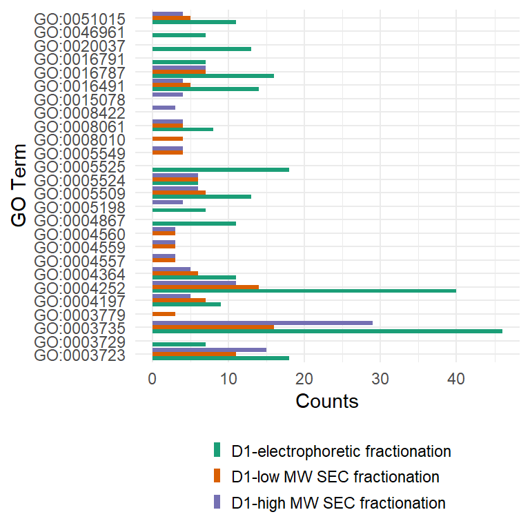

```r
BP_4ggplot <- melt(BP)
#BP_4ggplot$Function_short <- substr(BP_4ggplot$Function,1,15)
BP_4ggplot <- BP_4ggplot %>%
  mutate(Function_short = extract_goterm(Function))
ggplot(BP_4ggplot, aes(x=Function_short, y=value, fill=variable)) +
  geom_bar(stat='identity', position='dodge') +
  theme_minimal() +
  scale_fill_brewer(palette="Dark2") +
  theme(legend.position="bottom") +
  theme(legend.key.size = unit(0.15, 'cm')) +
  guides(fill=guide_legend(nrow=3, byrow=TRUE)) +
  ylab("Counts") +
  xlab("GO Term") +
  labs(fill = "") +
  coord_flip() +
  theme(legend.title = element_blank())
```

```r
################################# cellular.component
t_BP <- as.data.frame(table(GO_1$Gene.Ontology..cellular.component.))
t_BP_sorted <- arrange(t_BP, desc(Freq))
t_BP_sorted_1 <- t_BP_sorted[c(1:20),]
t_BP <- as.data.frame(table(GO_2$Gene.Ontology..cellular.component.))
t_BP_sorted <- arrange(t_BP, desc(Freq))
t_BP_sorted_2 <- t_BP_sorted[c(1:20),]
t_BP <- as.data.frame(table(GO_3$Gene.Ontology..cellular.component.))
t_BP_sorted <- arrange(t_BP, desc(Freq))
t_BP_sorted_3 <- t_BP_sorted[c(1:20),]
BP <- merge(t_BP_sorted_1, t_BP_sorted_2,
            all = TRUE,
            by = "Var1")
BP <- merge(BP, t_BP_sorted_3, all = TRUE, by = "Var1")

colnames(BP) <- c("Function", "B","AF","TF")
kable(BP)
```

| Function | B | AF | TF |
| --- | --- | --- | --- |
| chaperonin-containing T-complex [GO:0005832] | NA | 4 | 4 |
| chitin-based extracellular matrix [GO:0062129] | NA | 4 | 3 |
| cytoplasm [GO:0005737] | 116 | 66 | 64 |
| cytoplasm [GO:0005737]; lysosome [GO:0005764] | NA | 3 | NA |
| cytoplasm [GO:0005737]; mitochondrion [GO:0005739] | NA | NA | 5 |
| cytoplasm [GO:0005737]; nucleus [GO:0005634] | 18 | 6 | 5 |
| cytoplasm [GO:0005737]; nucleus [GO:0005634]; proteasome core complex [GO:0005839]; proteasome core complex, beta-subunit complex [GO:0019774] | NA | 5 | 5 |
| cytosol [GO:0005829] | 45 | 28 | 28 |
| cytosol [GO:0005829]; nucleus [GO:0005634] | 12 | NA | NA |
| cytosolic large ribosomal subunit [GO:0022625] | 30 | 15 | 24 |
| cytosolic small ribosomal subunit [GO:0022627] | 13 | 8 | 7 |
| endoplasmic reticulum membrane [GO:0005789] | 15 | NA | NA |
| extracellular region [GO:0005576] | 22 | 14 | 14 |
| extracellular space [GO:0005615] | 36 | 13 | 11 |
| extracellular space [GO:0005615]; lysosome [GO:0005764] | 12 | 7 | 6 |
| lysosome [GO:0005764] | NA | 6 | 7 |
| membrane [GO:0016020] | 44 | 8 | 14 |
| mitochondrial inner membrane [GO:0005743] | 8 | NA | NA |
| mitochondrial large ribosomal subunit [GO:0005762] | 7 | NA | NA |
| mitochondrial matrix [GO:0005759] | 7 | 5 | 5 |
| mitochondrial respiratory chain complex I [GO:0005747] | 17 | NA | NA |
| mitochondrial small ribosomal subunit [GO:0005763] | 10 | NA | 7 |
| mitochondrion [GO:0005739] | 54 | 28 | 28 |
| mitochondrion [GO:0005739]; oxoglutarate dehydrogenase complex [GO:0045252] | NA | 4 | NA |
| nucleus [GO:0005634] | 21 | 12 | 9 |
| peroxisome [GO:0005777] | 14 | 8 | 9 |
| plasma membrane [GO:0005886] | 19 | NA | 5 |
| ribonucleoprotein complex [GO:1990904]; ribosome [GO:0005840] | NA | 4 | NA |

```r
kable(subset(BP[,1], is.na(BP[,3]) == TRUE & !is.na(BP[,2]) == TRUE))
```

| x |
| --- |
| cytosol [GO:0005829]; nucleus [GO:0005634] |
| endoplasmic reticulum membrane [GO:0005789] |
| mitochondrial inner membrane [GO:0005743] |
| mitochondrial large ribosomal subunit [GO:0005762] |
| mitochondrial respiratory chain complex I [GO:0005747] |
| mitochondrial small ribosomal subunit [GO:0005763] |
| plasma membrane [GO:0005886] |

```r
kable(subset(BP[,1], is.na(BP[,2]) == TRUE & !is.na(BP[,3]) == TRUE))
```

| x |
| --- |
| chaperonin-containing T-complex [GO:0005832] |
| chitin-based extracellular matrix [GO:0062129] |
| cytoplasm [GO:0005737]; lysosome [GO:0005764] |
| cytoplasm [GO:0005737]; nucleus [GO:0005634]; proteasome core complex [GO:0005839]; proteasome core complex, beta-subunit complex [GO:0019774] |
| lysosome [GO:0005764] |
| mitochondrion [GO:0005739]; oxoglutarate dehydrogenase complex [GO:0045252] |
| ribonucleoprotein complex [GO:1990904]; ribosome [GO:0005840] |

```r
kable(subset(BP[,1], is.na(BP[,4]) == TRUE & !is.na(BP[,3]) == TRUE))
```

| x |
| --- |
| cytoplasm [GO:0005737]; lysosome [GO:0005764] |
| mitochondrion [GO:0005739]; oxoglutarate dehydrogenase complex [GO:0045252] |
| ribonucleoprotein complex [GO:1990904]; ribosome [GO:0005840] |

```r
kable(subset(BP[,1], is.na(BP[,3]) == TRUE & !is.na(BP[,4]) == TRUE))
```

| x |
| --- |
| cytoplasm [GO:0005737]; mitochondrion [GO:0005739] |
| mitochondrial small ribosomal subunit [GO:0005763] |
| plasma membrane [GO:0005886] |

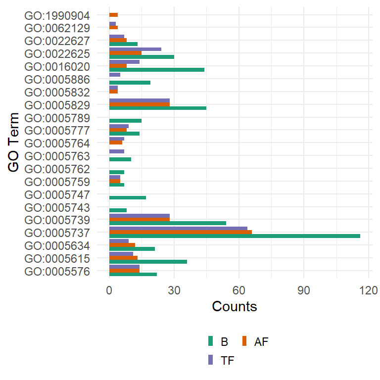

```r
BP_4ggplot <- melt(BP)
#BP_4ggplot$Function_short <- substr(BP_4ggplot$Function,1,15)
BP_4ggplot <- BP_4ggplot %>%
  mutate(Function_short = extract_goterm(Function))
ggplot(BP_4ggplot, aes(x=Function_short, y=value, fill=variable)) +
  geom_bar(stat='identity', position='dodge') +
  theme_minimal() +
  scale_fill_brewer(palette="Dark2") +
  theme(legend.position="bottom") +
  theme(legend.key.size = unit(0.15, 'cm')) +
  guides(fill=guide_legend(nrow=2, byrow=TRUE)) +
  ylab("Counts") +
  xlab("GO Term") +
  labs(fill = "") +
  coord_flip() +
  theme(legend.title = element_blank())
```

## 5.2 B

```r
#compare B to pool from 0609
B_raw <- readRDS(file = "results_v002/results_run1_mqpar_extracts_2gether_E4_D1_B_LFQ_combined_txt_proteinGroups.txt_Unique.RDS")
B_raw <- B_raw[[1]]
B <- dplyr::select(B_raw, contains("Pool_G"))
B <- apply(B, 1, any)
fasta <- c()
for (i in 1:length(B_raw$FASTA)){
  tmp <- strsplit(B_raw$FASTA[i],split='\\|')[[1]][2]
  fasta <- c(fasta,tmp)
}
B <- as.data.frame(cbind(B, fasta))
aj_raw <- readRDS(file = "results_v002/results_run1_mqpar_extracts_2gether_E4_D1_a-j_LFQ_combined_txt_proteinGroups.txt_Unique.RDS")
aj_raw <- aj_raw[[1]]
aj <- dplyr::select(aj_raw, contains("Pool"))
aj <- apply(aj, 1, any)
fasta <- c()
for (i in 1:length(aj_raw$FASTA)){
  tmp <- strsplit(aj_raw$FASTA[i],split='\\|')[[1]][2]
  fasta <- c(fasta,tmp)
}
aj <- as.data.frame(cbind(aj, fasta))
B_aj_comparison  <- merge(B, aj,
                          all = TRUE,
                          by = "fasta")

B_aj_comparison$B <- as.logical(B_aj_comparison$B)
B_aj_comparison$aj <- as.logical(B_aj_comparison$aj)

B <- B_aj_comparison$fasta[B_aj_comparison$B]
B <- B[!is.na(B)]
aj <- B_aj_comparison$fasta[B_aj_comparison$aj]
aj <- aj[!is.na(aj)]
#D1_uni <- GetProteinGOInfo(B)
#saveRDS(D1_uni,"./go_terms/graph3_B_B_uni.RDS")
GO_1 <- readRDS("./go_terms/graph3_B_B_uni.RDS")
#aj <- GetProteinGOInfo(aj)
#saveRDS(aj,"./go_terms/graph3_B_aj_uni.RDS")
GO_2 <- readRDS("./go_terms/graph3_B_aj_uni.RDS")

################################# Biological process
t_BP <- as.data.frame(table(GO_1$Gene.Ontology..biological.process.))
t_BP_sorted <- arrange(t_BP, desc(Freq))
t_BP_sorted_1 <- t_BP_sorted[c(1:20),]
t_BP <- as.data.frame(table(GO_2$Gene.Ontology..biological.process.))
t_BP_sorted <- arrange(t_BP, desc(Freq))
t_BP_sorted_2 <- t_BP_sorted[c(1:20),]
#t_BP <- as.data.frame(table(GO[[3]]$Gene.ontology..biological.process.))
#t_BP_sorted <- arrange(t_BP, desc(Freq))
#t_BP_sorted_3 <- t_BP_sorted[c(1:20),]
BP <- merge(t_BP_sorted_1, t_BP_sorted_2,
            all = TRUE,
            by = "Var1")
#BP <- merge(BP, t_BP_sorted_3, all = TRUE, by = "Var1")


colnames(BP) <- c("Function", "D1","D2")
kable(BP)
```

| Function | D1 | D2 |
| --- | --- | --- |
| bioluminescence [GO:0008218]; fatty-acyl-CoA biosynthetic process [GO:0046949]; long-chain fatty acid metabolic process [GO:0001676] | 6 | NA |
| carbohydrate metabolic process [GO:0005975] | 15 | 7 |
| carbohydrate metabolic process [GO:0005975]; chitin catabolic process [GO:0006032] | 10 | 3 |
| ceramide biosynthetic process [GO:0046513]; sphingomyelin catabolic process [GO:0006685] | NA | 3 |
| cytoplasmic translation [GO:0002181] | 6 | 6 |
| dephosphorylation [GO:0016311] | 6 | NA |
| fatty acid beta-oxidation [GO:0006635] | 12 | 8 |
| fatty acid biosynthetic process [GO:0006633] | 6 | 4 |
| glutathione metabolic process [GO:0006749] | 13 | 6 |
| L-ascorbic acid biosynthetic process [GO:0019853] | 7 | NA |
| lipid metabolic process [GO:0006629] | 6 | NA |
| mitochondrial electron transport, cytochrome c to oxygen [GO:0006123] | 5 | NA |
| mitochondrial electron transport, NADH to ubiquinone [GO:0006120] | 9 | NA |
| mitochondrial electron transport, ubiquinol to cytochrome c [GO:0006122] | NA | 3 |
| multicellular organism reproduction [GO:0032504] | 11 | 3 |
| negative regulation of peptidase activity [GO:0010466] | 11 | NA |
| nitrogen compound metabolic process [GO:0006807] | 6 | NA |
| peptide catabolic process [GO:0043171]; proteolysis [GO:0006508] | NA | 4 |
| proteasomal protein catabolic process [GO:0010498] | NA | 4 |
| proteasomal protein catabolic process [GO:0010498]; ubiquitin-dependent protein catabolic process [GO:0006511] | NA | 3 |
| proteasome-mediated ubiquitin-dependent protein catabolic process [GO:0043161] | 10 | 9 |
| protein folding [GO:0006457] | 10 | 6 |
| proteolysis [GO:0006508] | 61 | 19 |
| proteolysis involved in protein catabolic process [GO:0051603]; regulation of catalytic activity [GO:0050790] | NA | 4 |
| proton motive force-driven ATP synthesis [GO:0015986] | 6 | 6 |
| regulation of muscle contraction [GO:0006937]; skeletal muscle contraction [GO:0003009] | NA | 3 |
| sensory perception of smell [GO:0007608] | NA | 3 |
| translation [GO:0006412] | 35 | 22 |

```r
kable(BP[is.na(BP[,3])==TRUE,1])
```

| x |
| --- |
| bioluminescence [GO:0008218]; fatty-acyl-CoA biosynthetic process [GO:0046949]; long-chain fatty acid metabolic process [GO:0001676] |
| dephosphorylation [GO:0016311] |
| L-ascorbic acid biosynthetic process [GO:0019853] |
| lipid metabolic process [GO:0006629] |
| mitochondrial electron transport, cytochrome c to oxygen [GO:0006123] |
| mitochondrial electron transport, NADH to ubiquinone [GO:0006120] |
| negative regulation of peptidase activity [GO:0010466] |
| nitrogen compound metabolic process [GO:0006807] |

```r
kable(BP[is.na(BP[,2])==TRUE,1])
```

| x |
| --- |
| ceramide biosynthetic process [GO:0046513]; sphingomyelin catabolic process [GO:0006685] |
| mitochondrial electron transport, ubiquinol to cytochrome c [GO:0006122] |
| peptide catabolic process [GO:0043171]; proteolysis [GO:0006508] |
| proteasomal protein catabolic process [GO:0010498] |
| proteasomal protein catabolic process [GO:0010498]; ubiquitin-dependent protein catabolic process [GO:0006511] |
| proteolysis involved in protein catabolic process [GO:0051603]; regulation of catalytic activity [GO:0050790] |
| regulation of muscle contraction [GO:0006937]; skeletal muscle contraction [GO:0003009] |
| sensory perception of smell [GO:0007608] |

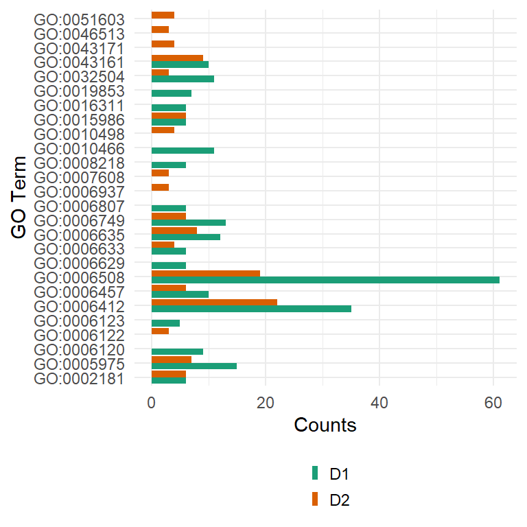

```r
BP_4ggplot <- melt(BP)
#BP_4ggplot$Function_short <- substr(BP_4ggplot$Function,1,15)
BP_4ggplot <- BP_4ggplot %>%
  mutate(Function_short = extract_goterm(Function))
ggplot(BP_4ggplot, aes(x=Function_short, y=value, fill=variable)) +
  geom_bar(stat='identity', position='dodge') +
  theme_minimal() +
  scale_fill_brewer(palette="Dark2") +
  theme(legend.position="bottom") +
  theme(legend.key.size = unit(0.15, 'cm')) +
  guides(fill=guide_legend(nrow=2, byrow=TRUE)) +
  ylab("Counts") +
  xlab("GO Term") +
  labs(fill = "") +
  coord_flip() +
  theme(legend.title = element_blank())
```

```r
################################# molecular function
t_BP <- as.data.frame(table(GO_1$Gene.Ontology..molecular.function.))
t_BP_sorted <- arrange(t_BP, desc(Freq))
t_BP_sorted_1 <- t_BP_sorted[c(1:20),]
t_BP <- as.data.frame(table(GO_2$Gene.Ontology..molecular.function.))
t_BP_sorted <- arrange(t_BP, desc(Freq))
t_BP_sorted_2 <- t_BP_sorted[c(1:20),]
#t_BP <- as.data.frame(table(GO_3$Gene.Ontology..molecular.function.))
#t_BP_sorted <- arrange(t_BP, desc(Freq))
#t_BP_sorted_3 <- t_BP_sorted[c(1:20),]
BP <- merge(t_BP_sorted_1, t_BP_sorted_2,
            all = TRUE,
            by = "Var1")
#BP <- merge(BP, t_BP_sorted_3, all = TRUE, by = "Var1")
results_comp <- c(results_comp,sum(is.na(BP[2])))
length_comp <- c(length_comp, length(BP[,1]))
colnames(BP) <- c("Function", "D1","D2")
kable(BP)
```

| Function | D1 | D2 |
| --- | --- | --- |
| acid sphingomyelin phosphodiesterase activity [GO:0061750]; hydrolase activity, acting on glycosyl bonds [GO:0016798]; metal ion binding [GO:0046872]; phosphoric diester hydrolase activity [GO:0008081… | NA | 3 |
| actin filament binding [GO:0051015] | 11 | 5 |
| actin filament binding [GO:0051015]; calcium ion binding [GO:0005509]; calcium-dependent protein binding [GO:0048306] | NA | 3 |
| ATP binding [GO:0005524]; ATP hydrolysis activity [GO:0016887]; ATP-dependent protein folding chaperone [GO:0140662]; unfolded protein binding [GO:0051082] | 6 | 6 |
| ATP binding [GO:0005524]; ATP hydrolysis activity [GO:0016887]; peptidase activity [GO:0008233]; proteasome-activating activity [GO:0036402] | 6 | 6 |
| calcium ion binding [GO:0005509] | 13 | 8 |
| calcium ion binding [GO:0005509]; calcium-dependent phospholipid binding [GO:0005544] | NA | 3 |
| chitin binding [GO:0008061] | NA | 3 |
| chitin binding [GO:0008061]; chitinase activity [GO:0004568] | 8 | NA |
| cysteine-type endopeptidase activity [GO:0004197] | 9 | 5 |
| DNA binding [GO:0003677]; protein heterodimerization activity [GO:0046982]; structural constituent of chromatin [GO:0030527] | NA | 3 |
| endopeptidase activity [GO:0004175]; threonine-type endopeptidase activity [GO:0004298] | NA | 3 |
| glutathione transferase activity [GO:0004364] | 11 | 5 |
| GTP binding [GO:0005525]; GTPase activity [GO:0003924] | 18 | 3 |
| heme binding [GO:0020037]; iron ion binding [GO:0005506]; monooxygenase activity [GO:0004497]; oxidoreductase activity, acting on paired donors, with incorporation or reduction of molecular oxygen [GO… | 13 | NA |
| hydrolase activity [GO:0016787] | 16 | 6 |
| mRNA binding [GO:0003729] | 7 | NA |
| oxidoreductase activity [GO:0016491] | 14 | 5 |
| phosphatase activity [GO:0016791] | 7 | NA |
| proton-transporting ATPase activity, rotational mechanism [GO:0046961] | 7 | NA |
| RNA binding [GO:0003723] | 15 | 4 |
| RNA binding [GO:0003723]; structural constituent of ribosome [GO:0003735] | 18 | 16 |
| serine-type endopeptidase activity [GO:0004252] | 40 | 8 |
| serine-type endopeptidase inhibitor activity [GO:0004867] | 11 | NA |
| structural constituent of ribosome [GO:0003735] | 46 | 24 |
| structural molecule activity [GO:0005198] | 7 | 5 |

```r
kable(BP[is.na(BP[,3])==TRUE,1])
```

| x |
| --- |
| chitin binding [GO:0008061]; chitinase activity [GO:0004568] |
| heme binding [GO:0020037]; iron ion binding [GO:0005506]; monooxygenase activity [GO:0004497]; oxidoreductase activity, acting on paired donors, with incorporation or reduction of molecular oxygen [GO… |
| mRNA binding [GO:0003729] |
| phosphatase activity [GO:0016791] |
| proton-transporting ATPase activity, rotational mechanism [GO:0046961] |
| serine-type endopeptidase inhibitor activity [GO:0004867] |

```r
kable(BP[is.na(BP[,2])==TRUE,1])
```

| x |
| --- |
| acid sphingomyelin phosphodiesterase activity [GO:0061750]; hydrolase activity, acting on glycosyl bonds [GO:0016798]; metal ion binding [GO:0046872]; phosphoric diester hydrolase activity [GO:0008081… |
| actin filament binding [GO:0051015]; calcium ion binding [GO:0005509]; calcium-dependent protein binding [GO:0048306] |
| calcium ion binding [GO:0005509]; calcium-dependent phospholipid binding [GO:0005544] |
| chitin binding [GO:0008061] |
| DNA binding [GO:0003677]; protein heterodimerization activity [GO:0046982]; structural constituent of chromatin [GO:0030527] |
| endopeptidase activity [GO:0004175]; threonine-type endopeptidase activity [GO:0004298] |

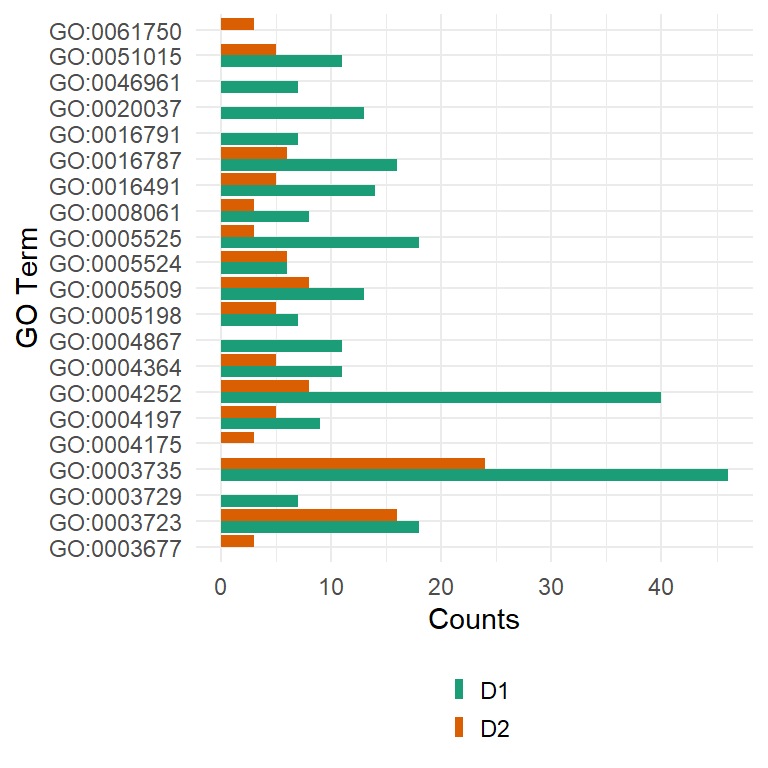

```r
BP_4ggplot <- melt(BP)
#BP_4ggplot$Function_short <- substr(BP_4ggplot$Function,1,15)
BP_4ggplot <- BP_4ggplot %>%
  mutate(Function_short = extract_goterm(Function))
ggplot(BP_4ggplot, aes(x=Function_short, y=value, fill=variable)) +
  geom_bar(stat='identity', position='dodge') +
  theme_minimal() +
  scale_fill_brewer(palette="Dark2") +
  theme(legend.position="bottom") +
  theme(legend.key.size = unit(0.15, 'cm')) +
  guides(fill=guide_legend(nrow=2, byrow=TRUE)) +
  ylab("Counts") +
  xlab("GO Term") +
  labs(fill = "") +
  coord_flip() +
  theme(legend.title = element_blank())
```

```r
################################# molecular function
t_BP <- as.data.frame(table(GO_1$Gene.Ontology..cellular.component.))
t_BP_sorted <- arrange(t_BP, desc(Freq))
t_BP_sorted_1 <- t_BP_sorted[c(1:20),]
t_BP <- as.data.frame(table(GO_2$Gene.Ontology..cellular.component.))
t_BP_sorted <- arrange(t_BP, desc(Freq))
t_BP_sorted_2 <- t_BP_sorted[c(1:20),]
#t_BP <- as.data.frame(table(GO_3$Gene.Ontology..cellular.component.))
#t_BP_sorted <- arrange(t_BP, desc(Freq))
#t_BP_sorted_3 <- t_BP_sorted[c(1:20),]
BP <- merge(t_BP_sorted_1, t_BP_sorted_2,
            all = TRUE,
            by = "Var1")
#BP <- merge(BP, t_BP_sorted_3, all = TRUE, by = "Var1")

colnames(BP) <- c("Function", "D1","D2")
kable(BP)
```

| Function | D1 | D2 |
| --- | --- | --- |
| chaperonin-containing T-complex [GO:0005832] | NA | 4 |
| cytoplasm [GO:0005737] | 116 | 59 |
| cytoplasm [GO:0005737]; mitochondrion [GO:0005739] | NA | 4 |
| cytoplasm [GO:0005737]; nucleus [GO:0005634] | 18 | 5 |
| cytosol [GO:0005829] | 45 | 27 |
| cytosol [GO:0005829]; mitochondrion [GO:0005739] | NA | 4 |
| cytosol [GO:0005829]; nucleus [GO:0005634] | 12 | NA |
| cytosolic large ribosomal subunit [GO:0022625] | 30 | 24 |
| cytosolic small ribosomal subunit [GO:0022627] | 13 | 10 |
| endoplasmic reticulum membrane [GO:0005789] | 15 | NA |
| eukaryotic 43S preinitiation complex [GO:0016282]; eukaryotic 48S preinitiation complex [GO:0033290]; eukaryotic translation initiation factor 3 complex [GO:0005852] | NA | 4 |
| extracellular region [GO:0005576] | 22 | 9 |
| extracellular space [GO:0005615] | 36 | 9 |
| extracellular space [GO:0005615]; lysosome [GO:0005764] | 12 | 8 |
| membrane [GO:0016020] | 44 | 8 |
| mitochondrial inner membrane [GO:0005743] | 8 | NA |
| mitochondrial large ribosomal subunit [GO:0005762] | 7 | NA |
| mitochondrial matrix [GO:0005759] | 7 | 6 |
| mitochondrial respiratory chain complex I [GO:0005747] | 17 | NA |
| mitochondrial small ribosomal subunit [GO:0005763] | 10 | NA |
| mitochondrion [GO:0005739] | 54 | 30 |
| nucleus [GO:0005634] | 21 | 7 |
| peroxisome [GO:0005777] | 14 | 9 |
| plasma membrane [GO:0005886] | 19 | 4 |
| ribonucleoprotein complex [GO:1990904]; ribosome [GO:0005840] | NA | 4 |
| troponin complex [GO:0005861] | NA | 4 |

```r
kable(BP[is.na(BP[,3])==TRUE,1])
```

| x |
| --- |
| cytosol [GO:0005829]; nucleus [GO:0005634] |
| endoplasmic reticulum membrane [GO:0005789] |
| mitochondrial inner membrane [GO:0005743] |
| mitochondrial large ribosomal subunit [GO:0005762] |
| mitochondrial respiratory chain complex I [GO:0005747] |
| mitochondrial small ribosomal subunit [GO:0005763] |

```r
kable(BP[is.na(BP[,2])==TRUE,1])
```

| x |
| --- |
| chaperonin-containing T-complex [GO:0005832] |
| cytoplasm [GO:0005737]; mitochondrion [GO:0005739] |
| cytosol [GO:0005829]; mitochondrion [GO:0005739] |
| eukaryotic 43S preinitiation complex [GO:0016282]; eukaryotic 48S preinitiation complex [GO:0033290]; eukaryotic translation initiation factor 3 complex [GO:0005852] |
| ribonucleoprotein complex [GO:1990904]; ribosome [GO:0005840] |
| troponin complex [GO:0005861] |

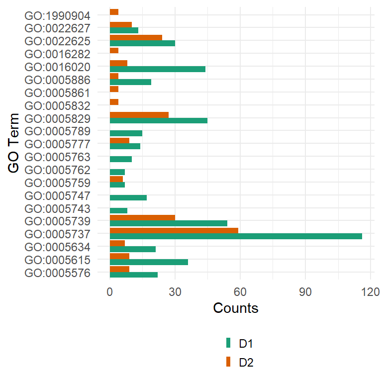

```r
BP_4ggplot <- melt(BP)
#BP_4ggplot$Function_short <- substr(BP_4ggplot$Function,1,15)
BP_4ggplot <- BP_4ggplot %>%
  mutate(Function_short = extract_goterm(Function))
ggplot(BP_4ggplot, aes(x=Function_short, y=value, fill=variable)) +
  geom_bar(stat='identity', position='dodge') +
  theme_minimal() +
  scale_fill_brewer(palette="Dark2") +
  theme(legend.position="bottom") +
  theme(legend.key.size = unit(0.15, 'cm')) +
  guides(fill=guide_legend(nrow=2, byrow=TRUE)) +
  ylab("Counts") +
  xlab("GO Term") +
  labs(fill = "") +
  coord_flip() +
  theme(legend.title = element_blank())
```

## 5.3 C

```r
#############################
# D2
###############################
data <- readRDS(file = "results_v002/results_run1_mqpar_extracts_2gether_D2_LFQ_combined_txt_proteinGroups.txt_Unique.RDS")
data <- data[[1]]

data_D2_pool <- dplyr::select(data, contains("Gesamt"))
data_D2_pool <- apply(data_D2_pool, 1, any)
data_D2_fractions <- dplyr::select(data, contains("20"))
data_D2_fractions <- apply(data_D2_fractions, 1, any)
data_D2 <- as.data.frame(cbind(data_D2_pool,data_D2_fractions))

fasta <- c()
for (i in 1:length(data$FASTA)){
  tmp <- strsplit(data$FASTA[i],split='\\|')[[1]][2]
  fasta <- c(fasta,tmp)
}

pool <- as.logical(data_D2$data_D2_pool)
fractions <- as.logical(data_D2$data_D2_fractions)

pool <- fasta[pool]
pool <- pool[!is.na(pool)]
fractions <- fasta[fractions]
fractions <- fractions[!is.na(fractions)]
#pool <- GetProteinGOInfo(pool)
#saveRDS(pool,"./go_terms/graph3_C_pool_uni.RDS")
GO1<- readRDS("./go_terms/graph3_C_pool_uni.RDS")
#fractions <- GetProteinGOInfo(fractions)
#saveRDS(fractions,"./go_terms/graph3_C_fractions_uni.RDS")
GO_2 <- readRDS("./go_terms/graph3_C_fractions_uni.RDS")

################################# Biological process
t_BP <- as.data.frame(table(GO_1$Gene.Ontology..biological.process.))
t_BP_sorted <- arrange(t_BP, desc(Freq))
t_BP_sorted_1 <- t_BP_sorted[c(1:20),]
t_BP <- as.data.frame(table(GO_2$Gene.Ontology..biological.process.))
t_BP_sorted <- arrange(t_BP, desc(Freq))
t_BP_sorted_2 <- t_BP_sorted[c(1:20),]
#t_BP <- as.data.frame(table(GO[[3]]$Gene.ontology..biological.process.))
#t_BP_sorted <- arrange(t_BP, desc(Freq))
#t_BP_sorted_3 <- t_BP_sorted[c(1:20),]
BP <- merge(t_BP_sorted_1, t_BP_sorted_2,
            all = TRUE,
            by = "Var1")
#BP <- merge(BP, t_BP_sorted_3, all = TRUE, by = "Var1")

colnames(BP) <- c("Function", "D1","D2")
kable(BP)
```

| Function | D1 | D2 |
| --- | --- | --- |
| anatomical structure morphogenesis [GO:0009653]; cell differentiation [GO:0030154] | NA | 4 |
| bioluminescence [GO:0008218]; fatty-acyl-CoA biosynthetic process [GO:0046949]; long-chain fatty acid metabolic process [GO:0001676] | 6 | NA |
| carbohydrate metabolic process [GO:0005975] | 15 | 8 |
| carbohydrate metabolic process [GO:0005975]; chitin catabolic process [GO:0006032] | 10 | 7 |
| cellular potassium ion homeostasis [GO:0030007]; cellular sodium ion homeostasis [GO:0006883]; potassium ion import across plasma membrane [GO:1990573]; sodium ion export across plasma membrane [GO:00… | NA | 4 |
| cytoplasmic translation [GO:0002181] | 6 | 6 |
| dephosphorylation [GO:0016311] | 6 | NA |
| fatty acid beta-oxidation [GO:0006635] | 12 | 9 |
| fatty acid biosynthetic process [GO:0006633] | 6 | NA |
| glutathione metabolic process [GO:0006749] | 13 | 9 |
| L-ascorbic acid biosynthetic process [GO:0019853] | 7 | NA |
| lipid metabolic process [GO:0006629] | 6 | NA |
| long-chain fatty-acyl-CoA metabolic process [GO:0035336] | NA | 7 |
| mitochondrial electron transport, cytochrome c to oxygen [GO:0006123] | 5 | 5 |
| mitochondrial electron transport, NADH to ubiquinone [GO:0006120] | 9 | 10 |
| mitochondrial electron transport, ubiquinol to cytochrome c [GO:0006122] | NA | 5 |
| multicellular organism reproduction [GO:0032504] | 11 | 8 |
| negative regulation of peptidase activity [GO:0010466] | 11 | 6 |
| nitrogen compound metabolic process [GO:0006807] | 6 | NA |
| proteasome-mediated ubiquitin-dependent protein catabolic process [GO:0043161] | 10 | 9 |
| protein folding [GO:0006457] | 10 | 5 |
| protein import into mitochondrial matrix [GO:0030150] | NA | 5 |
| proteolysis [GO:0006508] | 61 | 34 |
| proton motive force-driven ATP synthesis [GO:0015986] | 6 | 8 |
| translation [GO:0006412] | 35 | 29 |
| transmembrane transport [GO:0055085] | NA | 7 |

```r
kable(BP[is.na(BP[,3])==TRUE,1])
```

| x |
| --- |
| bioluminescence [GO:0008218]; fatty-acyl-CoA biosynthetic process [GO:0046949]; long-chain fatty acid metabolic process [GO:0001676] |
| dephosphorylation [GO:0016311] |
| fatty acid biosynthetic process [GO:0006633] |
| L-ascorbic acid biosynthetic process [GO:0019853] |
| lipid metabolic process [GO:0006629] |
| nitrogen compound metabolic process [GO:0006807] |

```r
kable(BP[is.na(BP[,2])==TRUE,1])
```

| x |
| --- |
| anatomical structure morphogenesis [GO:0009653]; cell differentiation [GO:0030154] |
| cellular potassium ion homeostasis [GO:0030007]; cellular sodium ion homeostasis [GO:0006883]; potassium ion import across plasma membrane [GO:1990573]; sodium ion export across plasma membrane [GO:00… |
| long-chain fatty-acyl-CoA metabolic process [GO:0035336] |
| mitochondrial electron transport, ubiquinol to cytochrome c [GO:0006122] |
| protein import into mitochondrial matrix [GO:0030150] |
| transmembrane transport [GO:0055085] |

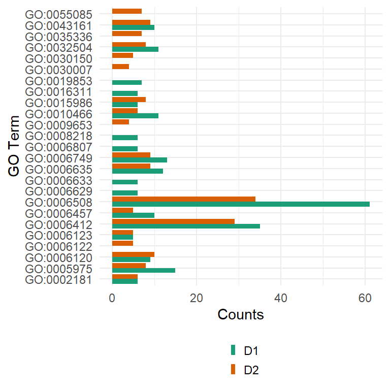

```r
BP_4ggplot <- melt(BP)
#BP_4ggplot$Function_short <- substr(BP_4ggplot$Function,1,15)
BP_4ggplot <- BP_4ggplot %>%
  mutate(Function_short = extract_goterm(Function))
ggplot(BP_4ggplot, aes(x=Function_short, y=value, fill=variable)) +
  geom_bar(stat='identity', position='dodge') +
  theme_minimal() +
  scale_fill_brewer(palette="Dark2") +
  theme(legend.position="bottom") +
  theme(legend.key.size = unit(0.15, 'cm')) +
  guides(fill=guide_legend(nrow=2, byrow=TRUE)) +
  ylab("Counts") +
  xlab("GO Term") +
  labs(fill = "") +
  coord_flip() +
  theme(legend.title = element_blank())
```

```r
################################# molecular function
t_BP <- as.data.frame(table(GO_1$Gene.Ontology..molecular.function.))
t_BP_sorted <- arrange(t_BP, desc(Freq))
t_BP_sorted_1 <- t_BP_sorted[c(1:20),]
t_BP <- as.data.frame(table(GO_2$Gene.Ontology..molecular.function.))
t_BP_sorted <- arrange(t_BP, desc(Freq))
t_BP_sorted_2 <- t_BP_sorted[c(1:20),]
#t_BP <- as.data.frame(table(GO_3$Gene.Ontology..molecular.function.))
#t_BP_sorted <- arrange(t_BP, desc(Freq))
#t_BP_sorted_3 <- t_BP_sorted[c(1:20),]
BP <- merge(t_BP_sorted_1, t_BP_sorted_2,
            all = TRUE,
            by = "Var1")
#BP <- merge(BP, t_BP_sorted_3, all = TRUE, by = "Var1")
results_comp <- c(results_comp,sum(is.na(BP[2])))
length_comp <- c(length_comp,length(BP[,1]))
colnames(BP) <- c("Function", "D1","D2")
kable(BP)
```

| Function | D1 | D2 |
| --- | --- | --- |
| actin filament binding [GO:0051015] | 11 | 6 |
| alcohol-forming fatty acyl-CoA reductase activity [GO:0102965]; fatty-acyl-CoA reductase (alcohol-forming) activity [GO:0080019] | NA | 7 |
| ATP binding [GO:0005524]; ATP hydrolysis activity [GO:0016887]; ATP-dependent protein folding chaperone [GO:0140662]; unfolded protein binding [GO:0051082] | 6 | 6 |
| ATP binding [GO:0005524]; ATP hydrolysis activity [GO:0016887]; peptidase activity [GO:0008233]; proteasome-activating activity [GO:0036402] | 6 | 6 |
| ATPase activator activity [GO:0001671] | NA | 5 |
| calcium ion binding [GO:0005509] | 13 | 11 |
| chitin binding [GO:0008061]; chitinase activity [GO:0004568] | 8 | 5 |
| cysteine-type endopeptidase activity [GO:0004197] | 9 | 8 |
| glutathione transferase activity [GO:0004364] | 11 | 9 |
| GTP binding [GO:0005525]; GTPase activity [GO:0003924] | 18 | 12 |
| heme binding [GO:0020037]; iron ion binding [GO:0005506]; monooxygenase activity [GO:0004497]; oxidoreductase activity, acting on paired donors, with incorporation or reduction of molecular oxygen [GO… | 13 | 26 |
| hydrolase activity [GO:0016787] | 16 | 7 |
| mRNA binding [GO:0003729] | 7 | NA |
| oxidoreductase activity [GO:0016491] | 14 | 7 |
| phosphatase activity [GO:0016791] | 7 | NA |
| proton-transporting ATPase activity, rotational mechanism [GO:0046961] | 7 | 7 |
| RNA binding [GO:0003723] | 15 | NA |
| RNA binding [GO:0003723]; structural constituent of ribosome [GO:0003735] | 18 | 17 |
| serine-type endopeptidase activity [GO:0004252] | 40 | 19 |
| serine-type endopeptidase inhibitor activity [GO:0004867] | 11 | 6 |
| structural constituent of chitin-based larval cuticle [GO:0008010] | NA | 18 |
| structural constituent of ribosome [GO:0003735] | 46 | 29 |
| structural molecule activity [GO:0005198] | 7 | NA |
| structural constituent of cuticle [GO:0042302] | NA | 14 |

```r
kable(BP[is.na(BP[,3])==TRUE,1])
```

| x |
| --- |
| mRNA binding [GO:0003729] |
| phosphatase activity [GO:0016791] |
| RNA binding [GO:0003723] |
| structural molecule activity [GO:0005198] |

```r
kable(BP[is.na(BP[,2])==TRUE,1])
```

| x |
| --- |
| alcohol-forming fatty acyl-CoA reductase activity [GO:0102965]; fatty-acyl-CoA reductase (alcohol-forming) activity [GO:0080019] |
| ATPase activator activity [GO:0001671] |
| structural constituent of chitin-based larval cuticle [GO:0008010] |
| structural constituent of cuticle [GO:0042302] |

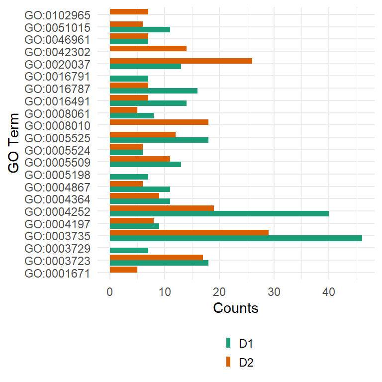

```r
BP_4ggplot <- melt(BP)
#BP_4ggplot$Function_short <- substr(BP_4ggplot$Function,1,15)
BP_4ggplot <- BP_4ggplot %>%
  mutate(Function_short = extract_goterm(Function))
ggplot(BP_4ggplot, aes(x=Function_short, y=value, fill=variable)) +
  geom_bar(stat='identity', position='dodge') +
  theme_minimal() +
  scale_fill_brewer(palette="Dark2") +
  theme(legend.position="bottom") +
  theme(legend.key.size = unit(0.15, 'cm')) +
  guides(fill=guide_legend(nrow=2, byrow=TRUE)) +
  ylab("Counts") +
  xlab("GO Term") +
  labs(fill = "") +
  coord_flip() +
  theme(legend.title = element_blank())
```

```r
################################# cellular.component
t_BP <- as.data.frame(table(GO_1$Gene.Ontology..cellular.component.))
t_BP_sorted <- arrange(t_BP, desc(Freq))
t_BP_sorted_1 <- t_BP_sorted[c(1:20),]
t_BP <- as.data.frame(table(GO_2$Gene.Ontology..cellular.component.))
t_BP_sorted <- arrange(t_BP, desc(Freq))
t_BP_sorted_2 <- t_BP_sorted[c(1:20),]
#t_BP <- as.data.frame(table(GO_3$Gene.Ontology..cellular.component.))
#t_BP_sorted <- arrange(t_BP, desc(Freq))
#t_BP_sorted_3 <- t_BP_sorted[c(1:20),]
BP <- merge(t_BP_sorted_1, t_BP_sorted_2,
            all = TRUE,
            by = "Var1")
#BP <- merge(BP, t_BP_sorted_3, all = TRUE, by = "Var1")

colnames(BP) <- c("Function", "D1","D2")
kable(BP)
```

| Function | D1 | D2 |
| --- | --- | --- |
| chitin-based extracellular matrix [GO:0062129] | NA | 18 |
| cytoplasm [GO:0005737] | 116 | 62 |
| cytoplasm [GO:0005737]; nucleus [GO:0005634] | 18 | 7 |
| cytosol [GO:0005829] | 45 | 23 |
| cytosol [GO:0005829]; nucleus [GO:0005634] | 12 | NA |
| cytosolic large ribosomal subunit [GO:0022625] | 30 | 30 |
| cytosolic small ribosomal subunit [GO:0022627] | 13 | 12 |
| endoplasmic reticulum membrane [GO:0005789] | 15 | 13 |
| extracellular region [GO:0005576] | 22 | 17 |
| extracellular space [GO:0005615] | 36 | 24 |
| extracellular space [GO:0005615]; lysosome [GO:0005764] | 12 | 7 |
| intracellular membrane-bounded organelle [GO:0043231]; membrane [GO:0016020]; peroxisome [GO:0005777] | NA | 7 |
| membrane [GO:0016020] | 44 | 76 |
| membrane [GO:0016020]; mitochondrion [GO:0005739] | NA | 9 |
| mitochondrial inner membrane [GO:0005743] | 8 | 13 |
| mitochondrial large ribosomal subunit [GO:0005762] | 7 | NA |
| mitochondrial matrix [GO:0005759] | 7 | NA |
| mitochondrial respiratory chain complex I [GO:0005747] | 17 | 22 |
| mitochondrial small ribosomal subunit [GO:0005763] | 10 | NA |
| mitochondrion [GO:0005739] | 54 | 32 |
| nucleus [GO:0005634] | 21 | 12 |
| peroxisome [GO:0005777] | 14 | 7 |
| plasma membrane [GO:0005886] | 19 | 19 |
| extracellular matrix [GO:0031012] | NA | 13 |

```r
kable(BP[is.na(BP[,3])==TRUE,1])
```

| x |
| --- |
| cytosol [GO:0005829]; nucleus [GO:0005634] |
| mitochondrial large ribosomal subunit [GO:0005762] |
| mitochondrial matrix [GO:0005759] |
| mitochondrial small ribosomal subunit [GO:0005763] |

```r
kable(BP[is.na(BP[,2])==TRUE,1])
```

| x |
| --- |
| chitin-based extracellular matrix [GO:0062129] |
| intracellular membrane-bounded organelle [GO:0043231]; membrane [GO:0016020]; peroxisome [GO:0005777] |
| membrane [GO:0016020]; mitochondrion [GO:0005739] |
| extracellular matrix [GO:0031012] |

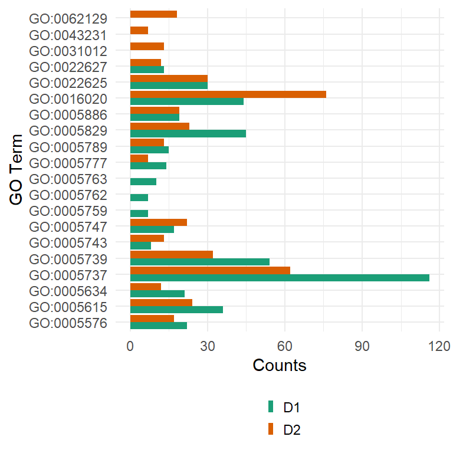

```r
BP_4ggplot <- melt(BP)
#BP_4ggplot$Function_short <- substr(BP_4ggplot$Function,1,15)
BP_4ggplot <- BP_4ggplot %>%
  mutate(Function_short = extract_goterm(Function))
ggplot(BP_4ggplot, aes(x=Function_short, y=value, fill=variable)) +
  geom_bar(stat='identity', position='dodge') +
  theme_minimal() +
  scale_fill_brewer(palette="Dark2") +
  theme(legend.position="bottom") +
  theme(legend.key.size = unit(0.15, 'cm')) +
  guides(fill=guide_legend(nrow=2, byrow=TRUE)) +
  ylab("Counts") +
  xlab("GO Term") +
  labs(fill = "") +
  coord_flip() +
  theme(legend.title = element_blank())
```

# 6 Grafik 4

- nicht notwendig

# 7 Results comparison

```r
print(results_comp)
```

```
## [1] 9 5 8 3 9 2 6 4
```

```r
print(length_comp)
```

```
## [1] 29 33 33 23 29 29 26 24
```

```r
print("Graph2")
```

```
## [1] "Graph2"
```

```r
print(c("A","B","B","C"))
```

```
## [1] "A" "B" "B" "C"
```

```r
print("Graph3")
```

```
## [1] "Graph3"
```

```r
print(c("A","A","B","C"))
```

```
## [1] "A" "A" "B" "C"
```

```r
results_comp/length_comp*100
```

```
## [1] 31.034483 15.151515 24.242424 13.043478 31.034483  6.896552 23.076923
## [8] 16.666667
```

# 8 Versuche für Paper

## 8.1 versuch von B,AF,TF

- wenn ich alle verfügbaren GO Terms nehme bekomme ich…
  - bei B 21NA = 2.8%
  - bei AF 363 NA = 48,7%
  - bei TF 372 NA = 49,9%
  - in Summe 745 GO Terms wenn man es prozentuell rechnen will
- wenn ich alle verfügbaren GO Terme die mehr als 1x vorkommen bekomme ich
  - bei B 21NA = 11,41%
  - bei AF 69NA = 37,5%
  - bei TF 65NA = 35,32%
  - bei einer Summe von 184 GO Terms
- wenn ich nur die ersten 100 nehme
  - bei B 52NA = 50,48%
  - bei AF 52NA = 50,48%
  - bei TF 52NA = 50,48%
  - bei einer Summe von 103 GO Terms
- wenn ich nur die ersten 20 nehme
  - bei B 9 NA = 31%
  - bei AF 9 NA = 31%
  - bei TF 9 NA = 31%
  - bei einer Summe von 29 GO Terms

## 8.2 versuch von 2D und 3D

- wenn ich alle verfügbaren GO Terms nehme bekomme ich…
  - bei 2D 96NA = 16,63%
  - bei 3D 36NA = 6,23%
  - in Summe 577 GO Terme wenn mans es prozentuell berechnen will
- wenn ich alle verfügbaren GO Terme die mehr als 1x vorkommen bekomme ich
  - bei 2D 96NA=49,48%
  - bei 3D 96NA=49,48%
  - in Summe 194 GO Terme
- wenn ich nur die ersten 100 nehme bekomme ich…
  - bei 2D 18NA = 15,25%
  - bei 3D 18NA = 15,25%
  - bei 118 GO Termen
- wenn ich nur die ersten 20 nehme bekomme ich…
  - bei 2D 3 NA = 13,04%
  - bei 3D 3 NA = 13,04%
  - bei 23 GO Termen